# Supervised Machine Learning: Classification Algorithms of Bank Marketing

- Introduction
- Data Preprocessing
- Data Exploration
- Data Preprocessing for Machine Learning
- Predictive Modelling: Methodology Overview
- Feature Selection
  - Repeated Startified 5-fold Cross Validation with 3 repetitions
  - Full Set of Features
  - F-Score
  - Mutual Information
  - Random Forest Importance
  - Summary of Feature Selection
- Data Sampling and Splitting
- Cross Validation and Hyperparameter Tuning
  - Stratified 5-fold Cross Validation
  - K Nearest Neighbor (KNN) Hyperparameter Tuning and Visualization
  - Decision Tree (DT) Hyperparameter Tuning and Visualization
  - Random Forest Hyperparameter Tuning and Visualization
  - Gaussian Naive Bayes Hyperparameter Tuning and Visualization
  - SVM Hyperparameter Tuning and Visualization
  - Summary of AUC score of Hyperparameter Tuning with stratified 5-fold cross-validation
- Model Evaluation: Performance Comparison
  - Fit the classifiers with Stratified 10-fold Cross Validation
  - Summary of AUC score on Test data
  - Paired t-test comparison of AUC Scores of Tuned Classifiers
  - Classification Report
  - Confusion Matrix
- Limitations
- Summary and Conclusions
- References

```python
#!pip install --upgrade altair

#!pip install vega vega_datasets
```

```python
import altair as alt
alt.renderers.enable('notebook')
```

```
RendererRegistry.enable('notebook')
```

# Introduction

The effectiveness of marketing campaigns is constantly challenged by rapid technological, social and economic changes over the years. Data related with direct marketing campaigns, based on phone calls, of a Portuguese banking institution was obtained from UCI Machine Learning Repository (https://archive.ics.uci.edu/ml/datasets/Bank+Marketing). The dataset consists on 41188 observations that present details related to the bank client details, the last contact of the current marketing campaign, details on the contact from previous campaigns, as well as some external social and economic context indicators.

The descriptive features include 10 numeric and 11 categorical features including the `target feature` y renamed as "Subscribed".

#### Objectives:

Considering the nature of the dataset, the desired target feature identifies whether if a client subscribed or not to a term deposit at the bank. Therefore, the objective of the study is to predict if a client will subscribe (yes or no) to a term deposit.

```python
import pandas as pd
import numpy as np
import seaborn as sns
import matplotlib.pyplot as plt
import io
import requests
import warnings
warnings.filterwarnings("ignore")

from sklearn.model_selection import cross_val_score, RepeatedStratifiedKFold
import sklearn.metrics as metrics
from sklearn.ensemble import RandomForestClassifier
from sklearn import preprocessing
from sklearn import feature_selection as fs
from sklearn.neighbors import KNeighborsClassifier

pd.set_option('display.max_columns', None)

attributeNames = [
    'Age',
    'Job',
    'Marital',
    'Education',
    'Default',
    'Housing',
    'Loan',
    'Contact',
    'Month',
    'Day_Of_Week',
    'Duration',
    'Campaign',
    'Passed_Days',
    'Previous',
    'Previous_Outcome',
    'Emp_Var_Rate',
    'CPI',
    'CCI',
    'Euribor_3M',
    'No_of_Emp',
    'Subscribed']

df= pd.read_csv('S3768288_Data.csv', sep = ",", names = attributeNames, skiprows=1)
df.head()
```

|  | Age | Job | Marital | Education | Default | Housing | Loan | Contact | Month | Day_Of_Week | Duration | Campaign | Passed_Days | Previous | Previous_Outcome | Emp_Var_Rate | CPI | CCI | Euribor_3M | No_of_Emp | Subscribed |
| --- | --- | --- | --- | --- | --- | --- | --- | --- | --- | --- | --- | --- | --- | --- | --- | --- | --- | --- | --- | --- | --- |
| 0 | 56 | housemaid | married | basic.4y | no | no | no | telephone | may | mon | 261 | 1 | 999 | 0 | nonexistent | 1.1 | 93.994 | -36.4 | 4.857 | 5191.0 | no |
| 1 | 57 | services | married | high.school | unknown | no | no | telephone | may | mon | 149 | 1 | 999 | 0 | nonexistent | 1.1 | 93.994 | -36.4 | 4.857 | 5191.0 | no |
| 2 | 37 | services | married | high.school | no | yes | no | telephone | may | mon | 226 | 1 | 999 | 0 | nonexistent | 1.1 | 93.994 | -36.4 | 4.857 | 5191.0 | no |
| 3 | 40 | admin. | married | basic.6y | no | no | no | telephone | may | mon | 151 | 1 | 999 | 0 | nonexistent | 1.1 | 93.994 | -36.4 | 4.857 | 5191.0 | no |
| 4 | 56 | services | married | high.school | no | no | yes | telephone | may | mon | 307 | 1 | 999 | 0 | nonexistent | 1.1 | 93.994 | -36.4 | 4.857 | 5191.0 | no |

There dataset contains 41188 observations and 21 columns; from which 10 are numeric and 11 categorical features. Said data types matches with the attribute information and descriptions provided by the source. Features do not seem to need any conversion.

```python
df.shape
```

```
(41188, 21)
```

```python
df.dtypes #Correct dtypes vs. UCI description
```

```
Age                   int64
Job                  object
Marital              object
Education            object
Default              object
Housing              object
Loan                 object
Contact              object
Month                object
Day_Of_Week          object
Duration              int64
Campaign              int64
Passed_Days           int64
Previous              int64
Previous_Outcome     object
Emp_Var_Rate        float64
CPI                 float64
CCI                 float64
Euribor_3M          float64
No_of_Emp           float64
Subscribed           object
dtype: object
```

# Data preprocessing

Data preprocessing is a must in every analysis including machine learning. As the saying goes Garbage In, Garbage out, we will explore and investigate any unusual and missing values to prepare our dataset for further analysis.

### Check missing values

Data description stated that the dataset did not contain any missing or null values. Nontheless, a quick check will be performed to confirm there are not missing values in the dataset.

```python
df.isnull().sum()
```

```
Age                 0
Job                 0
Marital             0
Education           0
Default             0
Housing             0
Loan                0
Contact             0
Month               0
Day_Of_Week         0
Duration            0
Campaign            0
Passed_Days         0
Previous            0
Previous_Outcome    0
Emp_Var_Rate        0
CPI                 0
CCI                 0
Euribor_3M          0
No_of_Emp           0
Subscribed          0
dtype: int64
```

To evaluate further on the data, the main characteristics and summary statistics for categorical and numeric features (respectively) will be identified. The below descriptive summaries aim to provide a better overview of the each feature.

The summary statistics below for categorical features displays the total count of observations per feature, the number of unique values each of them has, the most common ('top') value for each feature and the frequency of said mode. It can be observed that 'Job' and 'Month' variables have the highest number of unique values (or labels).

```python
df.describe(include = np.object)
```

|  | Job | Marital | Education | Default | Housing | Loan | Contact | Month | Day_Of_Week | Previous_Outcome | Subscribed |
| --- | --- | --- | --- | --- | --- | --- | --- | --- | --- | --- | --- |
| count | 41188 | 41188 | 41188 | 41188 | 41188 | 41188 | 41188 | 41188 | 41188 | 41188 | 41188 |
| unique | 12 | 4 | 8 | 3 | 3 | 3 | 2 | 10 | 5 | 3 | 2 |
| top | admin. | married | university.degree | no | yes | no | cellular | may | thu | nonexistent | no |
| freq | 10422 | 24928 | 12168 | 32588 | 21576 | 33950 | 26144 | 13769 | 8623 | 35563 | 36548 |

The summary statistics below for numerica features presents the main descriptive statistics for each of the features. From this, i worth to note that on the 'Passed_Days' feature a maximum '999' value. Based on the data source, the '999' value on 'Passed_Days' means that the client was not previously contacted; so no changes will be made to the feature as of yet.

```python
df.describe(include = np.number).round(2)
```

|  | Age | Duration | Campaign | Passed_Days | Previous | Emp_Var_Rate | CPI | CCI | Euribor_3M | No_of_Emp |
| --- | --- | --- | --- | --- | --- | --- | --- | --- | --- | --- |
| count | 41188.00 | 41188.00 | 41188.00 | 41188.00 | 41188.00 | 41188.00 | 41188.00 | 41188.00 | 41188.00 | 41188.00 |
| mean | 40.02 | 258.29 | 2.57 | 962.48 | 0.17 | 0.08 | 93.58 | -40.50 | 3.62 | 5167.04 |
| std | 10.42 | 259.28 | 2.77 | 186.91 | 0.49 | 1.57 | 0.58 | 4.63 | 1.73 | 72.25 |
| min | 17.00 | 0.00 | 1.00 | 0.00 | 0.00 | -3.40 | 92.20 | -50.80 | 0.63 | 4963.60 |
| 25% | 32.00 | 102.00 | 1.00 | 999.00 | 0.00 | -1.80 | 93.08 | -42.70 | 1.34 | 5099.10 |
| 50% | 38.00 | 180.00 | 2.00 | 999.00 | 0.00 | 1.10 | 93.75 | -41.80 | 4.86 | 5191.00 |
| 75% | 47.00 | 319.00 | 3.00 | 999.00 | 0.00 | 1.40 | 93.99 | -36.40 | 4.96 | 5228.10 |
| max | 98.00 | 4918.00 | 56.00 | 999.00 | 7.00 | 1.40 | 94.77 | -26.90 | 5.04 | 5228.10 |

### Check unique values

Unique values for categorical features will be evaluated, checking for any unusual values thus far.

First, these categorical features will be identified, so that the unique values of each of them can be extracted. All of these unique values match with the attribute information provided by the dataset source.

```python
categorical_features = df.columns[df.dtypes == np.object].tolist()
categorical_features
```

```
['Job',
 'Marital',
 'Education',
 'Default',
 'Housing',
 'Loan',
 'Contact',
 'Month',
 'Day_Of_Week',
 'Previous_Outcome',
 'Subscribed']
```

```python
for categorical_feature in categorical_features:
    print(categorical_feature + ':')
    print(df[categorical_feature].unique())
    print('\n')
```

```
Job:
['housemaid' 'services' 'admin.' 'blue-collar' 'technician' 'retired'
 'management' 'unemployed' 'self-employed' 'unknown' 'entrepreneur'
 'student']


Marital:
['married' 'single' 'divorced' 'unknown']


Education:
['basic.4y' 'high.school' 'basic.6y' 'basic.9y' 'professional.course'
 'unknown' 'university.degree' 'illiterate']


Default:
['no' 'unknown' 'yes']


Housing:
['no' 'yes' 'unknown']


Loan:
['no' 'yes' 'unknown']


Contact:
['telephone' 'cellular']


Month:
['may' 'jun' 'jul' 'aug' 'oct' 'nov' 'dec' 'mar' 'apr' 'sep']


Day_Of_Week:
['mon' 'tue' 'wed' 'thu' 'fri']


Previous_Outcome:
['nonexistent' 'failure' 'success']


Subscribed:
['no' 'yes']
```

### Drop unnecessary features

Still under the Data preparation stage, it will be evaluated the drop of any unnecessary feature from the dataset. Based on the recommendation of the data source, the 'Duration' feature is known to highly affect the output target; if 'Duration'=0 then the target feature is negative. Therefore, 'Duration' should be discarded if the purpose of the study is to obtain a realistic predictive model. (UCI, 2014)

Below, only 'Duration' feature will be dropped from the dataset thus far. Shape and first observations are presented to confirm the correct removal of the column.

```python
df = df.drop(columns='Duration')
df.shape
```

```
(41188, 20)
```

```python
df.head()
```

|  | Age | Job | Marital | Education | Default | Housing | Loan | Contact | Month | Day_Of_Week | Campaign | Passed_Days | Previous | Previous_Outcome | Emp_Var_Rate | CPI | CCI | Euribor_3M | No_of_Emp | Subscribed |
| --- | --- | --- | --- | --- | --- | --- | --- | --- | --- | --- | --- | --- | --- | --- | --- | --- | --- | --- | --- | --- |
| 0 | 56 | housemaid | married | basic.4y | no | no | no | telephone | may | mon | 1 | 999 | 0 | nonexistent | 1.1 | 93.994 | -36.4 | 4.857 | 5191.0 | no |
| 1 | 57 | services | married | high.school | unknown | no | no | telephone | may | mon | 1 | 999 | 0 | nonexistent | 1.1 | 93.994 | -36.4 | 4.857 | 5191.0 | no |
| 2 | 37 | services | married | high.school | no | yes | no | telephone | may | mon | 1 | 999 | 0 | nonexistent | 1.1 | 93.994 | -36.4 | 4.857 | 5191.0 | no |
| 3 | 40 | admin. | married | basic.6y | no | no | no | telephone | may | mon | 1 | 999 | 0 | nonexistent | 1.1 | 93.994 | -36.4 | 4.857 | 5191.0 | no |
| 4 | 56 | services | married | high.school | no | no | yes | telephone | may | mon | 1 | 999 | 0 | nonexistent | 1.1 | 93.994 | -36.4 | 4.857 | 5191.0 | no |

# Data Exploration

Considering the dataset characteristics observed in the previous descriptive analysis, some visual exploration will be performed to complement the understanding of the variables. Following up, features and some of their most relevant interactions will be visualised in order to identify its relevance for further modelling.

## Univariate Analysis

### Age distribution

The Age distribution for the current campaign was mainly centered on late 30s and early 40s. Said age range matches with working and economically active population. Is worth notice to comment on the range of ages from 70s to late 90s, which appear in less frequently, but were still reached by the campaign.

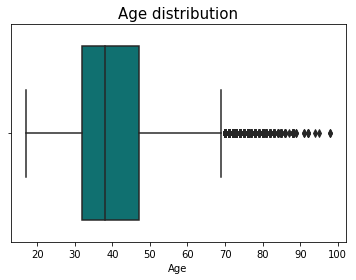

```python
sns.boxplot(df['Age'], color='teal').set_title('Age distribution', fontsize = 15)
plt.show();
```

### Job types

The Job Count Plot below presents "admin", "blue-collar" and "technician" as the most frequent occupations in the dataset. Based on this, administrative personal, industry manual workers and technicians are mainly contacted on the marketing campaign. It is important to consider that the count plot presents the reach of the campaign, and not necessarily the effectiveness of it on these "main occupations". Identifying the profession of the marketing campaign provides an insight of the current targeted market, and also on the opportunity targets that other occupations represent for future campaigns.

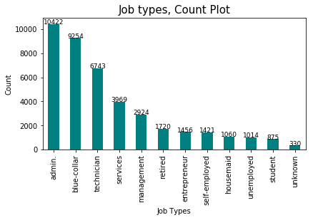

```python
j = df['Job'].value_counts().plot(kind = 'bar', color='teal')
j.set_xticklabels(j.get_xticklabels(), rotation = 90)
plt.tight_layout()
plt.ylabel('Count')
plt.xlabel('Job Types')
plt.title('Job types, Count Plot', fontsize = 15)
for p in j.patches:
    height = p.get_height()
    j.text(p.get_x()+p.get_width()/2., height + 0.1,height ,ha="center", fontsize=9)
```

### Education levels

The current marketing campaing has reached largely to inidividuals with a University and High School level. Seems interesting to observe that Professional course level is not reached as often as the mentioned main two. In that regard it might be relevant to evaluate the effectiveness of the current campaign on each of the different education levels.

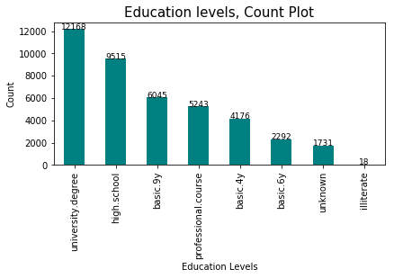

```python
ed = df['Education'].value_counts().plot(kind = 'bar', color='teal')
ed.set_xticklabels(ed.get_xticklabels(), rotation = 90)
plt.tight_layout()
plt.ylabel('Count')
plt.xlabel('Education Levels')
plt.title('Education levels, Count Plot', fontsize = 15)
for p in ed.patches:
    height = p.get_height()
    ed.text(p.get_x()+p.get_width()/2., height + 0.1,height ,ha="center", fontsize=9)
```

### Previous Outcome

The current marketing campaign was mainly targeted to new potential clients. The below Count Plot shows that the majority of the contacts made was to individuals with a nonexistent previous campaign outcome. Following in frequency are more failure cases than successes. What the visualisation might explain, is that the current campagin was oriented towards new potential clients rather, than focusing only on individuals already contacted.

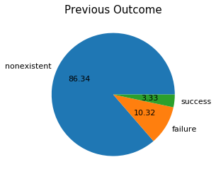

```python
df['Previous_Outcome'].value_counts().plot(kind='pie',autopct='%.2f', fontsize=11)
plt.title('Previous Outcome', fontsize = 15)
plt.ylabel(' ')
plt.show()
```

## Bivariate Analysis

Some of the features in the dataset are best observed and evaluated by their interaction with other variables. Below, some bivariate visualisations will provide a clearer understanding of the interaction dynamic of the features.

### Contact by Campaign

The below Bar Graph compares the number of contacts performed for each client, by each communication type (telephone and cellular). It reflects how landline telephone communications tend to implicate a larger number of calls per client. By having a less number of contacts per client, cellphone communications seem to be more effective at reaching the individuals, and obtaining a definite response with less calls.

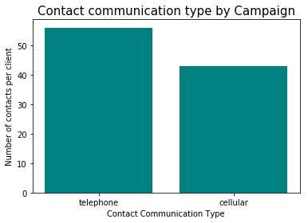

```python
plt.bar(df['Contact'], df['Campaign'], color='teal')
plt.ylabel('Number of contacts per client')
plt.xlabel('Contact Communication Type')
plt.title('Contact communication type by Campaign', fontsize =15)
plt.show();
```

### Previous Outcome by Housing Loan

Based on the Previous campaign Outcome and the current Housing Loan status per client, the Count Plot below reflects how the majority of individuals contacted during this campaign does have a Housing Loan. Each of the Previous campaign Outcomes (Non-existent, Failure and Success) presents a similar proportion of Housing loan responses: most have a Housing loan, followed by individuals who do not have a Housing loan, and a low proportion of 'unknown' status.

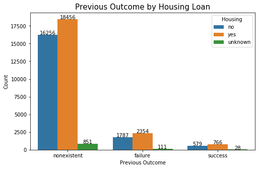

```python
fig, ax1 = plt.subplots(figsize=(8,5))
pohl = sns.countplot(x='Previous_Outcome',hue='Housing', data=df)
plt.title('Previous Outcome by Housing Loan', fontsize =15)
plt.ylabel('Count')
plt.xlabel('Previous Outcome')
for p in pohl.patches:
    height = p.get_height()
    pohl.text(p.get_x()+p.get_width()/2., height + 0.1,height ,ha="center")
```

### Previous Outcome by Personal Loan

Similar to the previous Housing loan visualisation, based on the Previous campaign Outcome and the current Personal Loan status per client, the Count Plot below reflects how the majority of individuals contacted during this campaign does not have a Personal Loan. Each of the Previous campaign Outcomes (Non-existent, Failure and Success) presents a similar proportion and distribution of Personal Loan responses: most have do not have a Personal loan, a considerable smaller proportion does have a Personal loan, and a low proportion of 'unknown' loan status.

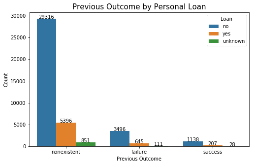

```python
fig, ax1 = plt.subplots(figsize=(8,5))
popl = sns.countplot(x='Previous_Outcome',hue='Loan', data=df)
plt.title('Previous Outcome by Personal Loan', fontsize =15)
plt.ylabel('Count')
plt.xlabel('Previous Outcome')
for p in popl.patches:
    height = p.get_height()
    popl.text(p.get_x()+p.get_width()/2., height + 0.1,height ,ha="center")
```

### Previous Outcome by Previous Contact

It results relevant to evaluate the Outcome of the Previous Campaign based on the number of contacts performed per client before this campaign. Based on the visualisation below, it can be observed that successful outcomes usually resultes from a larger number of contacts per client on the previous campaign. Is important to observe how the largest number of contacts on the previous campaign was 7 times, where the large majority was of less than 3 times per client. Is worth to note as well that the "non-existent" outcome clearly accounts for no previous contacts, as these are mainly new individuals contacted until the most recent campaign.

```python
# Filtering only the 2 columns needed
df_ct = df[['Previous', 'Previous_Outcome']]

# Creating a cross table
df_ct = pd.crosstab(index=df_ct["Previous"],
                  columns=df_ct["Previous_Outcome"])
```

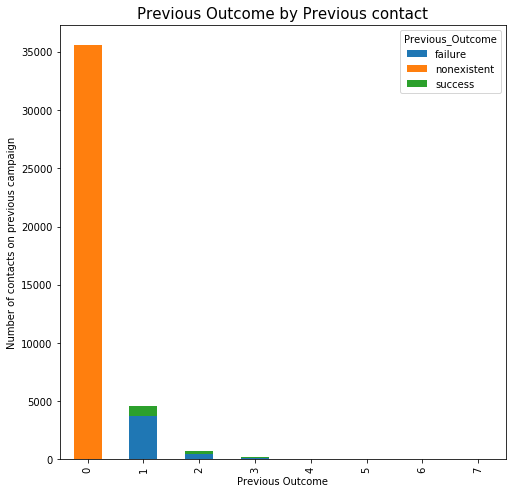

```python
df_ct.plot(kind="bar", figsize=(8,8), stacked=True);
plt.title('Previous Outcome by Previous contact', fontsize =15)
plt.ylabel('Number of contacts on previous campaign')
plt.xlabel('Previous Outcome')
plt.show();
```

### Euribor and CPI

The current marketing campaign took into account some external economic indices at the time each of the contacts were made. Euribor (Euro Interbank Offered Rate) is a rate of interest used as reference for setting the interest rate on loans. On the other hand, Consumer Price Index (CPI) is an estimate that measures the changes on the price level of representative items.

For this marketing campaign, the Euribor indicator is for a 3 month rate, and the CPI as a monthly indicator. Therefore the limited number of unique values on the rates generates a limited visualisation like the one below. It can be inferred from it that as the Euribor rate remained relatively low (below 2%) the CPI tended to be more evenly distributed. So that a wider variation on the price levels could be expected when the Euribor rate was low.

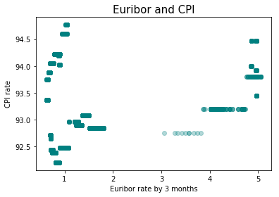

```python
euro = df['Euribor_3M']

plt.scatter(euro, df['CPI'], alpha = 0.3, color='teal')
plt.title('Euribor and CPI', fontsize = 15)
plt.xlabel('Euribor rate by 3 months')
plt.ylabel('CPI rate')
plt.show();
```

### Consumer Confidence Index and Consumer Price Index

The current marketing campaign took into account some external economic indices at the time each of the contacts were made. CCI and CPI are measures of the strength of the economy that can together provide an economic contextfor each of the contacts. The Consumer Price Index (CPI) is an estimate that measures the changes on the price level of representative items. While Consumer Confidence Index (CCI) is a monthly rate that assesses the overall 'health' of the economy.

The plot below displays a negative relation between the CPI and CCI values present in the dataset.The positive values for the CPI suggest positive changes in the price levels, while the low negative values of the CCI indicate a relative weakness on the economic situation. (OECD, 2020)

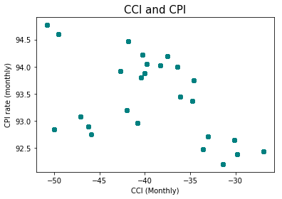

```python
plt.scatter(df['CCI'], df['CPI'], alpha = 0.3, color='teal')
plt.title('CCI and CPI', fontsize = 15)
plt.xlabel('CCI (Monthly)')
plt.ylabel('CPI rate (monthly)')
plt.show();
```

## Multivariate Analysis

The interactions between two features can be evaluated more in depth if relevant variables to their interaction are taken into account.

### Contact by Campaign, Previous Outcome status

Considering the previous evaluation of the number of contacts performed per client during the current campaign, and the type of communication (telephone or cellular), results relevant to identify the distribution by which these contacts made resulted based on the Previous campaign Outcome. The Bar Graph below reflects how landline and cellular communications had similar distributions for each of the previous outcome results. It also presents how for new potential clients (with a non-existent previous outcome) the number of contacts per client, on both types of communications (landline and cellular), was the highest. Successful Previous campaign Outcomes seem to be relatively less than non-existent and failed.

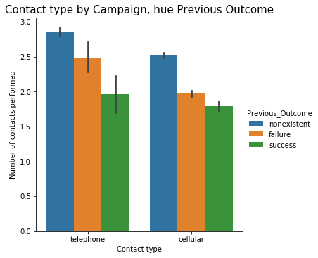

```python
sns.catplot(x="Contact", y="Campaign", hue="Previous_Outcome", kind="bar", data=df);
plt.title('Contact type by Campaign, hue Previous Outcome', fontsize =15)
plt.ylabel('Number of contacts performed')
plt.xlabel('Contact type')
plt.show();
```

### Previous Outcome by Previous contact, Housing Loan status

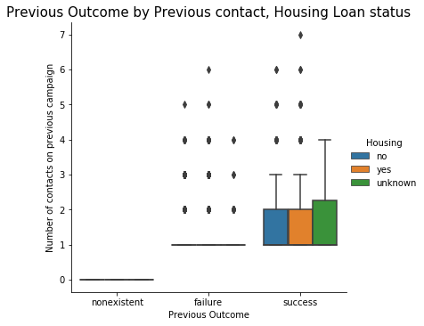

```python
sns.catplot(x="Previous_Outcome", y="Previous", hue="Housing", kind="box", data=df);
plt.title('Previous Outcome by Previous contact, Housing Loan status', fontsize =15)
plt.ylabel('Number of contacts on previous campaign')
plt.xlabel('Previous Outcome')
plt.show();
```

### Previous Outcome by Previous contact, Personal Loan status

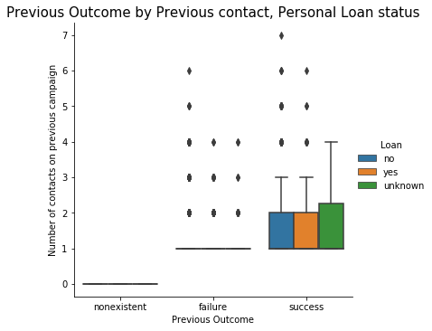

```python
sns.catplot(x="Previous_Outcome", y="Previous", hue="Loan", kind="box", data=df);
plt.title('Previous Outcome by Previous contact, Personal Loan status', fontsize =15)
plt.ylabel('Number of contacts on previous campaign')
plt.xlabel('Previous Outcome')
plt.show();
```

Based on a previous evaluation of the relation between the CPI and Euribor indices, the Previous Campaign Outcome is identified along, to help identify under which external economic rates context the diferent outcomes tended to happen. From the scatter plot below it can be observed that under a lower Euribor rate, most successful outcomes took place. Nonetheless, failure outcomes were also present under the same low Euribor rates. It is interesting to note, that for this current campaign, most of the non-existent outcomes (possibly first-time contacted clients) can be observed under a higher Euribor rate, and behaving on clear groups according to the possible CPI rate values.

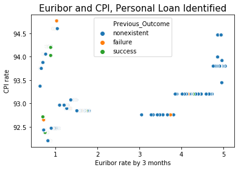

```python
sns.scatterplot(x="Euribor_3M", y="CPI", hue="Previous_Outcome", data=df)

plt.title('Euribor and CPI, Personal Loan Identified', fontsize = 15)
plt.xlabel('Euribor rate by 3 months')
plt.ylabel('CPI rate')
plt.show();
```

### Consumer Confidence Index and Consumer Price Index, Previous Outcome status

Considering the economic context reflected on the dataset CCI and CPI indicators, the Previous Outcome status is identified in the plot below. Based on the position of the Outocome categories, it can be inferred that most successful campaigns tend to occur on a not stronger economic situation (considering the CCI indicator values). It can also be observed that failed campaigns can occurred when there was a high change on the price levels (CPI), and when there was still an overall negative economic rate (CCI).

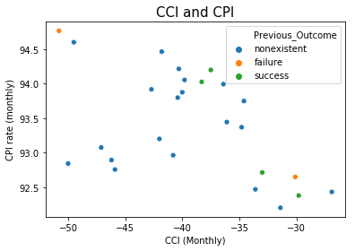

```python
sns.scatterplot(x="CCI", y="CPI", hue="Previous_Outcome", data=df)

plt.title('CCI and CPI', fontsize = 15)
plt.xlabel('CCI (Monthly)')
plt.ylabel('CPI rate (monthly)')
plt.show();
```

# Machine Learning Data Preparation

Considering the previous Data Preparation and Exploration the following data preprocessing involves the encoding of some features to facilitate the Machine Learning procedures, as well as some scaling

### Discretizing Numeric Features: Equal-frequency binning

The 'Age' numeric feature will be discretized using equal-frequency binning with 3 bins: namely "young", "middle-aged", and "old". 'Age' will be now a categorical feature after the discretization.

All unique (numeric) values will be firstly identified. Using a quantile-based discretization, these values will be distributed on an equal-frequency binning into the categories previously mentioned.

```python
NumericFeat = ['Age']
for col in NumericFeat:
    print('Before Discretizing unique values for ' + col)
    print(df[col].unique())
```

```
Before Discretizing unique values for Age
[56 57 37 40 45 59 41 24 25 29 35 54 46 50 39 30 55 49 34 52 58 32 38 44
 42 60 53 47 51 48 33 31 43 36 28 27 26 22 23 20 21 61 19 18 70 66 76 67
 73 88 95 77 68 75 63 80 62 65 72 82 64 71 69 78 85 79 83 81 74 17 87 91
 86 98 94 84 92 89]
```

```python
df['Age'] = pd.qcut(df['Age'], q=3, labels=['young', 'middle-aged', 'old'])
```

After discretization, the 3 categories can be observed for the 'Age' feature. The count for the values of each category can also be performed, identifying a higher frequency on the 'young' Age category.

```python
for col in NumericFeat:
    print('\nAfter transformation')
    print(df[col].unique())
    print('')
```

```
After transformation
[old, middle-aged, young]
Categories (3, object): [young < middle-aged < old]
```

```python
df['Age'].value_counts()
```

```
young          14754
middle-aged    13500
old            12934
Name: Age, dtype: int64
```

### Making Categorical Features Numeric: Integer Encoding (Ordinal)

Considering the nature of some features on the dataset, integer encoding will be applied to ordinal categorical features to preserve the order of the values; namely 'Age' and 'Education'.

A level mapping will be generated for each feature, defining the values according to the desired category order. These later will be replaced for the mapping values, so that instead of labels, 'Age' and 'Education' will now have numeric and ordered values.

#### Age - Encoding

```python
level_mapping_age = {'young': 0, 'middle-aged': 1, 'old': 2} #Apply level mapping
level_mapping_age
```

```
{'young': 0, 'middle-aged': 1, 'old': 2}
```

```python
df['Age'] = df['Age'].replace(level_mapping_age)
```

```python
df['Age'].head()
```

```
0    2
1    2
2    1
3    1
4    2
Name: Age, dtype: int64
```

#### Education - Encoding

```python
level_ed = {'illiterate': 0,'basic.4y': 1, 'basic.6y': 2, 'basic.9y': 3, 'high.school': 4,'professional.course': 5,
            'university.degree': 6, 'unknown': 7}
```

```python
df['Education'] = df['Education'].replace(level_ed)
```

#### Integer-Encoding check

The first 5 observations of the dataset are shown below to confirm that after the Integer-Encoding features 'Age' and 'Education' are now numeric values that account for a specific value order.

```python
df.head(5)
```

|  | Age | Job | Marital | Education | Default | Housing | Loan | Contact | Month | Day_Of_Week | Campaign | Passed_Days | Previous | Previous_Outcome | Emp_Var_Rate | CPI | CCI | Euribor_3M | No_of_Emp | Subscribed |
| --- | --- | --- | --- | --- | --- | --- | --- | --- | --- | --- | --- | --- | --- | --- | --- | --- | --- | --- | --- | --- |
| 0 | 2 | housemaid | married | 1 | no | no | no | telephone | may | mon | 1 | 999 | 0 | nonexistent | 1.1 | 93.994 | -36.4 | 4.857 | 5191.0 | no |
| 1 | 2 | services | married | 4 | unknown | no | no | telephone | may | mon | 1 | 999 | 0 | nonexistent | 1.1 | 93.994 | -36.4 | 4.857 | 5191.0 | no |
| 2 | 1 | services | married | 4 | no | yes | no | telephone | may | mon | 1 | 999 | 0 | nonexistent | 1.1 | 93.994 | -36.4 | 4.857 | 5191.0 | no |
| 3 | 1 | admin. | married | 2 | no | no | no | telephone | may | mon | 1 | 999 | 0 | nonexistent | 1.1 | 93.994 | -36.4 | 4.857 | 5191.0 | no |
| 4 | 2 | services | married | 4 | no | no | yes | telephone | may | mon | 1 | 999 | 0 | nonexistent | 1.1 | 93.994 | -36.4 | 4.857 | 5191.0 | no |

### Label Encoding Target Feature

Feature 'Subscribed' is designated as the target feature of the dataframe, so it will be renamed as 'target'.

A value count is presented to observe the distribution of the feature values.

```python
target = df['Subscribed']
Data = df.drop(columns='Subscribed')

target.value_counts()
```

```
no     36548
yes     4640
Name: Subscribed, dtype: int64
```

The target feature will now be label-encoded so that the 'positive class' value is '1' and 'negative class' is '0'. A value count is presented to verify the correct encoding.

```python
target = target.replace({'no': 0, 'yes':1})

target.value_counts()
```

```
0    36548
1     4640
Name: Subscribed, dtype: int64
```

### Making Categorical Features Numeric: One-hot encoding (Nominal)

As we proceed to nominal features, a double check will be made for all categorical features to inspect if there are still any other ordinal features to be label encoded.

Upon inspecting, as all categorical features are nominal, one-hot encoding will be applied.

First, all categorical features will be identified from the dataset, and for each categorical columns, a value count for each of the labels will be made.

```python
categorical_cols = Data.columns[Data.dtypes == np.object].tolist()
categorical_cols
```

```
['Job',
 'Marital',
 'Default',
 'Housing',
 'Loan',
 'Contact',
 'Month',
 'Day_Of_Week',
 'Previous_Outcome']
```

```python
for categorical in categorical_cols:
    print(categorical + ':')
    print(Data[categorical].value_counts())
    print('\n')
```

```
Job:
admin.           10422
blue-collar       9254
technician        6743
services          3969
management        2924
retired           1720
entrepreneur      1456
self-employed     1421
housemaid         1060
unemployed        1014
student            875
unknown            330
Name: Job, dtype: int64


Marital:
married     24928
single      11568
divorced     4612
unknown        80
Name: Marital, dtype: int64


Default:
no         32588
unknown     8597
yes            3
Name: Default, dtype: int64


Housing:
yes        21576
no         18622
unknown      990
Name: Housing, dtype: int64


Loan:
no         33950
```

[output cut: 24 more lines]

```

Day_Of_Week:
thu    8623
mon    8514
wed    8134
tue    8090
fri    7827
Name: Day_Of_Week, dtype: int64


Previous_Outcome:
nonexistent    35563
failure         4252
success         1373
Name: Previous_Outcome, dtype: int64
```

Appyling one-hot encoding making all categorical features binary, implies that any binary variables will only be encoded with one binary variable. On the other hand, non-binary variables or categorical features with more than 2 levels will be encoded with a standard one-hot encoding.

One-hot encoded nominal features will be stored under an updated data frame called 'df_encoded'.

```python
#One-Hot Encoding for Binary values
for col in categorical_cols:
    q = len(Data[col].unique())
    if (q == 2):
        Data[col] = pd.get_dummies(Data[col], drop_first=True)

#One-Hot Encoding for Non-Binary values
Data = pd.get_dummies(Data)
```

After One-Hot encoding, data tyes are presented below to verify that the identified categorical features are now numeric. The shape and data values are also evaluated by obtaining a random sample after the encoding, as well as some descriptive statistics that can now be obtained from these features.

```python
Data.dtypes
```

```
Age                               int64
Education                         int64
Contact                           uint8
Campaign                          int64
Passed_Days                       int64
Previous                          int64
Emp_Var_Rate                    float64
CPI                             float64
CCI                             float64
Euribor_3M                      float64
No_of_Emp                       float64
Job_admin.                        uint8
Job_blue-collar                   uint8
Job_entrepreneur                  uint8
Job_housemaid                     uint8
Job_management                    uint8
Job_retired                       uint8
Job_self-employed                 uint8
Job_services                      uint8
Job_student                       uint8
Job_technician                    uint8
Job_unemployed                    uint8
Job_unknown                       uint8
Marital_divorced                  uint8
Marital_married                   uint8
Marital_single                    uint8
Marital_unknown                   uint8
Default_no                        uint8
Default_unknown                   uint8
Default_yes                       uint8
Housing_no                        uint8
Housing_unknown                   uint8
Housing_yes                       uint8
Loan_no                           uint8
Loan_unknown                      uint8
Loan_yes                          uint8
Month_apr                         uint8
Month_aug                         uint8
Month_dec                         uint8
Month_jul                         uint8
Month_jun                         uint8
Month_mar                         uint8
Month_may                         uint8
Month_nov                         uint8
Month_oct                         uint8
Month_sep                         uint8
Day_Of_Week_fri                   uint8
Day_Of_Week_mon                   uint8
Day_Of_Week_thu                   uint8
Day_Of_Week_tue                   uint8
Day_Of_Week_wed                   uint8
Previous_Outcome_failure          uint8
Previous_Outcome_nonexistent      uint8
Previous_Outcome_success          uint8
dtype: object
```

```python
print(f'Shape of Data is {Data.shape}\n')

Data.sample(n=5, random_state=999)
```

```
Shape of Data is (41188, 54)
```

|  | Age | Education | Contact | Campaign | Passed_Days | Previous | Emp_Var_Rate | CPI | CCI | Euribor_3M | No_of_Emp | Job_admin. | Job_blue-collar | Job_entrepreneur | Job_housemaid | Job_management | Job_retired | Job_self-employed | Job_services | Job_student | Job_technician | Job_unemployed | Job_unknown | Marital_divorced | Marital_married | Marital_single | Marital_unknown | Default_no | Default_unknown | … |
| --- | --- | --- | --- | --- | --- | --- | --- | --- | --- | --- | --- | --- | --- | --- | --- | --- | --- | --- | --- | --- | --- | --- | --- | --- | --- | --- | --- | --- | --- | --- |
| 30370 | 2 | 4 | 0 | 3 | 999 | 1 | -1.8 | 93.075 | -47.1 | 1.365 | 5099.1 | 1 | 0 | 0 | 0 | 0 | 0 | 0 | 0 | 0 | 0 | 0 | 0 | 0 | 1 | 0 | 0 | 1 | 0 | … |
| 34765 | 1 | 5 | 0 | 4 | 999 | 0 | -1.8 | 92.893 | -46.2 | 1.266 | 5099.1 | 0 | 0 | 0 | 0 | 0 | 0 | 0 | 0 | 0 | 1 | 0 | 0 | 0 | 0 | 1 | 0 | 1 | 0 | … |
| 14618 | 1 | 4 | 0 | 5 | 999 | 0 | 1.4 | 93.918 | -42.7 | 4.961 | 5228.1 | 1 | 0 | 0 | 0 | 0 | 0 | 0 | 0 | 0 | 0 | 0 | 0 | 1 | 0 | 0 | 0 | 1 | 0 | … |
| 5673 | 0 | 2 | 1 | 1 | 999 | 0 | 1.1 | 93.994 | -36.4 | 4.857 | 5191.0 | 0 | 1 | 0 | 0 | 0 | 0 | 0 | 0 | 0 | 0 | 0 | 0 | 0 | 1 | 0 | 0 | 0 | 1 | … |
| 37545 | 2 | 5 | 0 | 3 | 999 | 1 | -2.9 | 92.201 | -31.4 | 0.869 | 5076.2 | 0 | 0 | 0 | 0 | 0 | 1 | 0 | 0 | 0 | 0 | 0 | 0 | 0 | 1 | 0 | 0 | 1 | 0 | … |

```python
Data.describe(include='all').round(3)
```

|  | Age | Education | Contact | Campaign | Passed_Days | Previous | Emp_Var_Rate | CPI | CCI | Euribor_3M | No_of_Emp | Job_admin. | Job_blue-collar | Job_entrepreneur | Job_housemaid | Job_management | Job_retired | Job_self-employed | Job_services | Job_student | Job_technician | Job_unemployed | Job_unknown | Marital_divorced | Marital_married | Marital_single | Marital_unknown | Default_no | Default_unknown | … |
| --- | --- | --- | --- | --- | --- | --- | --- | --- | --- | --- | --- | --- | --- | --- | --- | --- | --- | --- | --- | --- | --- | --- | --- | --- | --- | --- | --- | --- | --- | --- |
| count | 41188.000 | 41188.000 | 41188.000 | 41188.000 | 41188.000 | 41188.000 | 41188.000 | 41188.000 | 41188.000 | 41188.000 | 41188.000 | 41188.000 | 41188.000 | 41188.000 | 41188.000 | 41188.000 | 41188.000 | 41188.000 | 41188.000 | 41188.000 | 41188.000 | 41188.000 | 41188.000 | 41188.000 | 41188.000 | 41188.000 | 41188.000 | 41188.000 | 41188.000 | … |
| mean | 0.956 | 4.280 | 0.365 | 2.568 | 962.475 | 0.173 | 0.082 | 93.576 | -40.503 | 3.621 | 5167.036 | 0.253 | 0.225 | 0.035 | 0.026 | 0.071 | 0.042 | 0.035 | 0.096 | 0.021 | 0.164 | 0.025 | 0.008 | 0.112 | 0.605 | 0.281 | 0.002 | 0.791 | 0.209 | … |
| std | 0.819 | 1.702 | 0.482 | 2.770 | 186.911 | 0.495 | 1.571 | 0.579 | 4.628 | 1.734 | 72.252 | 0.435 | 0.417 | 0.185 | 0.158 | 0.257 | 0.200 | 0.183 | 0.295 | 0.144 | 0.370 | 0.155 | 0.089 | 0.315 | 0.489 | 0.449 | 0.044 | 0.406 | 0.406 | … |
| min | 0.000 | 0.000 | 0.000 | 1.000 | 0.000 | 0.000 | -3.400 | 92.201 | -50.800 | 0.634 | 4963.600 | 0.000 | 0.000 | 0.000 | 0.000 | 0.000 | 0.000 | 0.000 | 0.000 | 0.000 | 0.000 | 0.000 | 0.000 | 0.000 | 0.000 | 0.000 | 0.000 | 0.000 | 0.000 | … |
| 25% | 0.000 | 3.000 | 0.000 | 1.000 | 999.000 | 0.000 | -1.800 | 93.075 | -42.700 | 1.344 | 5099.100 | 0.000 | 0.000 | 0.000 | 0.000 | 0.000 | 0.000 | 0.000 | 0.000 | 0.000 | 0.000 | 0.000 | 0.000 | 0.000 | 0.000 | 0.000 | 0.000 | 1.000 | 0.000 | … |
| 50% | 1.000 | 4.000 | 0.000 | 2.000 | 999.000 | 0.000 | 1.100 | 93.749 | -41.800 | 4.857 | 5191.000 | 0.000 | 0.000 | 0.000 | 0.000 | 0.000 | 0.000 | 0.000 | 0.000 | 0.000 | 0.000 | 0.000 | 0.000 | 0.000 | 1.000 | 0.000 | 0.000 | 1.000 | 0.000 | … |
| 75% | 2.000 | 6.000 | 1.000 | 3.000 | 999.000 | 0.000 | 1.400 | 93.994 | -36.400 | 4.961 | 5228.100 | 1.000 | 0.000 | 0.000 | 0.000 | 0.000 | 0.000 | 0.000 | 0.000 | 0.000 | 0.000 | 0.000 | 0.000 | 0.000 | 1.000 | 1.000 | 0.000 | 1.000 | 0.000 | … |
| max | 2.000 | 7.000 | 1.000 | 56.000 | 999.000 | 7.000 | 1.400 | 94.767 | -26.900 | 5.045 | 5228.100 | 1.000 | 1.000 | 1.000 | 1.000 | 1.000 | 1.000 | 1.000 | 1.000 | 1.000 | 1.000 | 1.000 | 1.000 | 1.000 | 1.000 | 1.000 | 1.000 | 1.000 | 1.000 | … |

### Normalization: Min-Max Scaling

Having all categorical features now transformed into numerical features, as a good practice to prepare for Machine Learning, a 'Min-Max Scaling' normalisation will be performed on numerical features. By using Min-Max Scaling, the values for each descriptive feature will be scaled between 0 and 1.

The result of the scaling is an array of the transformed values, so these will be reincorporated into a dataframe.

```python
Data_copy = Data.copy()

from sklearn import preprocessing
Data_MinMax_scaler = preprocessing.MinMaxScaler()
Data_MinMax_scaler.fit(Data)
```

```
MinMaxScaler(copy=True, feature_range=(0, 1))
```

```python
Data = Data_MinMax_scaler.fit_transform(Data)
Data
```

```
array([[1.        , 0.14285714, 1.        , ..., 0.        , 1.        ,
        0.        ],
       [1.        , 0.57142857, 1.        , ..., 0.        , 1.        ,
        0.        ],
       [0.5       , 0.57142857, 1.        , ..., 0.        , 1.        ,
        0.        ],
       ...,
       [1.        , 0.85714286, 0.        , ..., 0.        , 1.        ,
        0.        ],
       [0.5       , 0.71428571, 0.        , ..., 0.        , 1.        ,
        0.        ],
       [1.        , 0.71428571, 0.        , ..., 1.        , 0.        ,
        0.        ]])
```

```python
Data = pd.DataFrame(Data, columns=Data_copy.columns)
Data.shape
```

```
(41188, 54)
```

# Predictive Modelling: Methodology Overview

To attain the objective of predicting the target feature, the predictive modeling process will be completed in the following order:

It is to be noted that five (5) classifiers were used to predict the target feature

- K-Nearest Neighbors (KNN)
- Decision Tree (DT)
- Random Forest (RF)
- Naive Bayes (NB)
- Support Vector Machine (SVM)
- First of all, data preparation and transformation were applied to the data prior application of machine learning techniques and classifiers.
  - Target feature was label encoded.
  - One hot encoded categorical features were transformed using Min-Max scaling.
- It will proceed to perform a **Feature Selection**, comparing the results of different feature selection methods namely, Full set of Features, F-score, Mutual Information, and Random Forest Importance to evaluate and select the most relevant features from the dataset. To evaluate the performance assessment, a **Cross validation of RepeatedStratifiedKFold with stratified 5-fold with 3 repetitions** was applied.
- Afterwards, a **data sample** of 5000 observations was obtained on the selected best features, in our case using the F-Score 10 selected best features.
- The data sample with the selected best features from F-Score was **split into the data and target features** into training and test sets (following a 70-30 proportion).
  - 3500 rows of training data data will be used for hyperparameter tuning phase.
  - 1500 rows of test data will be used for the performance comparison phase.
- A **Cross Validation and Hyperparameter Tuning** was performed for the KNN, Decision Tree, Random Forest, Naive Bayes, and Support Vector Machine classifiers. Specifically, cross validation of **StratifiedKFold with stratified 5-fold with no repetitions** and **Grid Search** were performed to identify the optimal parameters for each classifier.
  - Stratification ensures that the proportion of the two labels in both train and test sets are the same as the proportion in the full dataset.
  - The area under curve (AUC) is the performance metric.
- We then proceed to performance comparison, where we **fit** each tuned classifier with the best set of hyperparameter values on the test data in another **cross-validated** way to identify which tuned classifier outperforms the others.
  - A **10-fold stratified cross-validation with no repetition** with the same seed was applied in each of the classifiers.
  - Both phases involve cross-validation, thus effects of overfitting shall be quite limited.
  - The area under curve (AUC) is also the performance metric.
- Afterwards, a **pairwise t-test** was conducted between the **AUC score** between each of the tuned classifiers to evaluate the statistical significance of their performance.
  - A p-value smaller than 0.05 indicates a statistically significant difference.
- Lastly, we compare the classifiers with its respective **classification reports specifically recall scores and its confusion matrices**.

# Feature Selection

Before fitting a model, it is good to do feature selection to check whether reducing feature can help achieve better performance. The objective of feature selection is to use a number of features instead of using all features that may lead to poor performance in general.

The feature selection methods that are going to be used are:

- F-score
- Mutual Information and
- Random Forest

All three methods above are the filter methods. The filter methods look at the relationship between each descriptive feature and the target feature using different measures. Using the method, we can check the important features according to the number of features that we are going to select. Lastly, we will compute the average of the performance for each method and make a comparison between all three methods and also the performance with full set features to see which one gives the best performance.

### Repeated Startified 5-fold Cross Validation with 3 repetitions

The first thing that needs to be done is defining the wrapper. In this case, we are using the default parameter `(n = 5)` of nearest neighbour classifier.

```python
# Using default parameter
clf = KNeighborsClassifier()
```

Using the `RepeatedStratifiedKFold`, 5-fold cross-validation with 3 repititions will be done. `random_state = 999` will set the results so when the code is being re-run again, the result will be replicated.

```python
cv_method = RepeatedStratifiedKFold(n_splits = 5,
                                   n_repeats = 3,
                                   random_state = 999)
```

`accuracy` score will be used as the scoring metric.

```python
scoring_metric = 'accuracy'
```

### Performance with Full set of features

Before doing feature selection, it's important to check the performance when all features in the dataset are used.

Using the classifier, cross validation method and scoring metric defined in previous section, cross-validation will be performed using the `cross_val_score` function.

```python
cv_results_full = cross_val_score(estimator=clf,
                                  X= Data,
                                  y= target,
                                  cv=cv_method,
                                  scoring = scoring_metric)
```

`cv_results_full` array contains 15 values of the 5-fold-combinations with 3 repititions (3 x 5).

```python
cv_results_full
```

```
array([0.89536295, 0.89062879, 0.8884438 , 0.88940148, 0.89122253,
       0.89293518, 0.89196407, 0.89232824, 0.88903727, 0.89025131,
       0.88419519, 0.89196407, 0.88990046, 0.89146534, 0.89437902])
```

We will compute the average result of the `cv_results_full` array.

```python
cv_results_full.mean().round(3)
```

```
0.891
```

We can see that with 5-nearest neighbour classifier and using a full set of features from the dataset, we were able to achieve an average accuracy of 89.1%.

### Feature Selection Using F-Score

F-Score method is one of the filter feature selection method. This method is going to look at relationship between each descriptive feature with the target feature using **F-distribution**.

In all of the feature selection methods, we are going to select 10 best features out of the dataset and compare the average performance to see which feature selection gives the best accuracy and whether or not it will improve the performance from when full set features are used.

```python
num_features = 10
```

The methodology of using F-score is:

1) Defining template in `SelectKBest`

2) Using `fit_transform` for our data and target

3) Getting scores using `scores_` and sorting it from highest to lowest score

```python
fs_fit_fscore = fs.SelectKBest(fs.f_classif, k = num_features)
fs_fit_fscore.fit_transform(Data, target)
fs_indices_fscore = np.argsort(np.nan_to_num(fs_fit_fscore.scores_))[::-1][0:num_features]
fs_indices_fscore
```

```
array([10,  4, 53,  9,  6,  5, 52,  2, 41, 44])
```

```python
best_features_fscore = Data.columns[fs_indices_fscore].values
best_features_fscore
```

```
array(['No_of_Emp', 'Passed_Days', 'Previous_Outcome_success',
       'Euribor_3M', 'Emp_Var_Rate', 'Previous',
       'Previous_Outcome_nonexistent', 'Contact', 'Month_mar',
       'Month_oct'], dtype=object)
```

The array `best_feature_fscore` above shows the top 10 features in order of importance.

The score of importance of the features are given as per below.

```python
feature_importances_fscore = fs_fit_fscore.scores_[fs_indices_fscore]
feature_importances_fscore.round(3)
```

```
array([5926.611, 4861.173, 4577.561, 4309.479, 4023.83 , 2304.257,
       1602.2  ,  881.707,  872.291,  792.102])
```

The results of the best features and the scores can be compiled as per below:

```python
best_fscore = pd.DataFrame(best_features_fscore, columns = ['Best Features F-Score'])
best_fscore['Feature Importances'] = pd.DataFrame(feature_importances_fscore.round(3))
best_fscore
```

|  | Best Features F-Score | Feature Importances |
| --- | --- | --- |
| 0 | No_of_Emp | 5926.611 |
| 1 | Passed_Days | 4861.173 |
| 2 | Previous_Outcome_success | 4577.561 |
| 3 | Euribor_3M | 4309.479 |
| 4 | Emp_Var_Rate | 4023.830 |
| 5 | Previous | 2304.257 |
| 6 | Previous_Outcome_nonexistent | 1602.200 |
| 7 | Contact | 881.707 |
| 8 | Month_mar | 872.291 |
| 9 | Month_oct | 792.102 |

From the result above, it can be seen that the most important feature is `No_of_Emp` and the least important feature is `Month_oct` out of the 10 features (Note: result will change slightly in every run).

Defining the function below, we can plot different feature selection methods that will be used.

```python
import altair as alt

def plot_imp(best_features, scores, method_name, color):
    df = pd.DataFrame({'features': best_features, 'importances': scores})
    chart = alt.Chart(df, width=500,
                      title=method_name + ' Feature Importances'
                     ).mark_bar(opacity=0.75, color=color).encode(
        alt.X('features', title='Feature', sort=None, axis=alt.AxisConfig(labelAngle=45)),
        alt.Y('importances', title='Importance') )
    return chart
```

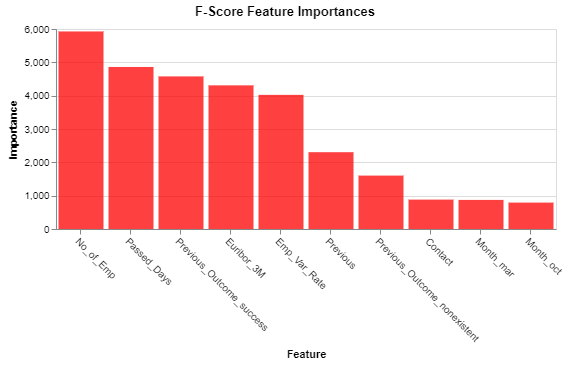

```python
plot_imp(best_features_fscore, feature_importances_fscore, 'F-Score', 'red')
```

Using the code below, we can select these 10 features. `shape` function is used to check the dimension of the data.

```python
Data.iloc[:,fs_indices_fscore].shape
```

```
(41188, 10)
```

Using the cross validation with 5-nearest neighbour classifier, F-Score feature selection is able to give an average mean of 89.3%.

In this case it means that we were able to improve the performance by 0.2% by selecting only 10 features which was supposed to be 54 features previously (average mean of 89.1% with full set of features).

```python
cv_results_fscore = cross_val_score(estimator=clf,
                                    X=Data.loc[:, best_features_fscore],
                                    y=target,
                                    cv=cv_method,
                                    scoring=scoring_metric)
cv_results_fscore.mean().round(3)
```

```
0.893
```

### Feature Selection Using Mutual Information

Feature selection using mutual information method is also a filter method that look at the relationships between each of the descriptive features with the target feature using `entropy` concept.

```python
fs_fit_mutual_info = fs.SelectKBest(fs.mutual_info_classif, k=num_features)
fs_fit_mutual_info.fit_transform(Data, target)
fs_indices_mutual_info = np.argsort(fs_fit_mutual_info.scores_)[::-1][0:num_features]
fs_indices_mutual_info
```

```
array([ 9,  7,  8, 10,  6,  4, 53, 52,  5,  2])
```

Below are the top 10 features that are selected by the mutual information method.

```python
best_features_mutual_info = Data.columns[fs_indices_mutual_info].values
best_features_mutual_info
```

```
array(['Euribor_3M', 'CPI', 'CCI', 'No_of_Emp', 'Emp_Var_Rate',
       'Passed_Days', 'Previous_Outcome_success',
       'Previous_Outcome_nonexistent', 'Previous', 'Contact'],
      dtype=object)
```

```python
feature_importances_mutual_info = fs_fit_mutual_info.scores_[fs_indices_mutual_info]
feature_importances_mutual_info.round(3)
```

```
array([0.074, 0.07 , 0.069, 0.063, 0.058, 0.039, 0.029, 0.022, 0.018,
       0.014])
```

```python
best_mutual_info = pd.DataFrame(best_features_mutual_info, columns = ['Best Features Mutual Info'])
best_mutual_info['Feature Importances'] = pd.DataFrame(feature_importances_mutual_info.round(3))
best_mutual_info
```

|  | Best Features Mutual Info | Feature Importances |
| --- | --- | --- |
| 0 | Euribor_3M | 0.074 |
| 1 | CPI | 0.070 |
| 2 | CCI | 0.069 |
| 3 | No_of_Emp | 0.063 |
| 4 | Emp_Var_Rate | 0.058 |
| 5 | Passed_Days | 0.039 |
| 6 | Previous_Outcome_success | 0.029 |
| 7 | Previous_Outcome_nonexistent | 0.022 |
| 8 | Previous | 0.018 |
| 9 | Contact | 0.014 |

As per the result above, `Euribor_3M` is the most important feature and `Contact` is the least important out of the top 10 features. (Note: result will change slightly in every run)

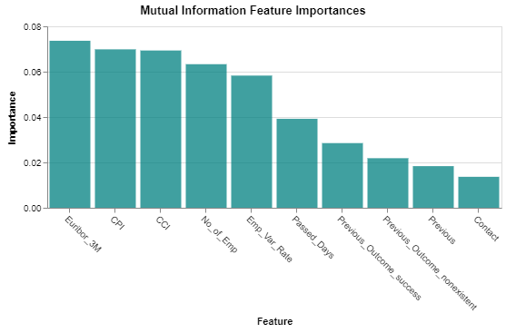

```python
plot_imp(best_features_mutual_info, feature_importances_mutual_info, 'Mutual Information', 'teal')
```

```python
cv_results_mutual_info = cross_val_score(estimator=clf,
                                         X=Data.loc[:, best_features_mutual_info],
                                         y=target,
                                         cv=cv_method,
                                         scoring=scoring_metric)
cv_results_mutual_info.mean().round(3)
```

```
0.889
```

The average result of performance from mutual information method is 88.9%. It is not performing as good as F-Score or the full set features. However, being able to only lose 0.2% after reducing around 44 columns means that mutual information method is also performing pretty well.

### Feature Selection Using Random Forest Importance

Random forest importance method is also another filter feature selection method. Random forest consists of decision trees. Each of the decision trees are created using random features and random observations, hence not all the trees see all features or all observations. This will help reduce the risk of over-fitting (The Wisdom of Crowds, 2018).

In classification, impurity is measured using Gini index. While for regression, the measure is measud using residual sum of squared.

When training a tree, how much each feature decreases the impurity can be computed. The more the impurity decreases, the more important the feature is. The average of the decrease of impurity from each feature will then be computed across trees in order to determine the importance of the feature.

In this report, RFI method will be performed using 100 trees as per below.

```python
model_rfi = RandomForestClassifier(n_estimators=100)
model_rfi.fit(Data, target)
fs_indices_rfi = np.argsort(model_rfi.feature_importances_)[::-1][0:num_features]
fs_indices_rfi
```

```
array([ 9,  3,  1, 10,  0,  4,  8,  7, 30, 32])
```

```python
best_features_rfi = Data.columns[fs_indices_rfi].values
best_features_rfi
```

```
array(['Euribor_3M', 'Campaign', 'Education', 'No_of_Emp', 'Age',
       'Passed_Days', 'CCI', 'CPI', 'Housing_no', 'Housing_yes'],
      dtype=object)
```

```python
feature_importances_rfi = model_rfi.feature_importances_[fs_indices_rfi]
feature_importances_rfi.round(3)
```

```
array([0.138, 0.11 , 0.092, 0.058, 0.054, 0.032, 0.027, 0.025, 0.023,
       0.023])
```

The data frame below compiles the result for the best features and the scores.

```python
best_rfi = pd.DataFrame(best_features_rfi, columns = ['Best Features RFI'])
best_rfi['Feature Importances'] = pd.DataFrame(feature_importances_rfi.round(3))
best_rfi
```

|  | Best Features RFI | Feature Importances |
| --- | --- | --- |
| 0 | Euribor_3M | 0.138 |
| 1 | Campaign | 0.110 |
| 2 | Education | 0.092 |
| 3 | No_of_Emp | 0.058 |
| 4 | Age | 0.054 |
| 5 | Passed_Days | 0.032 |
| 6 | CCI | 0.027 |
| 7 | CPI | 0.025 |
| 8 | Housing_no | 0.023 |
| 9 | Housing_yes | 0.023 |

The best features selected by RFI method are as per the table above. The most important feature is `Euribor_3M` while the least important one is the `Housing_yes`. (Note: result will change slightly in every run)

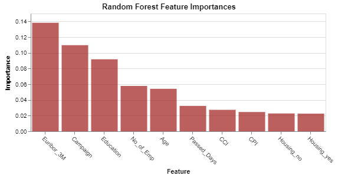

```python
plot_imp(best_features_rfi, feature_importances_rfi, 'Random Forest', 'brown')
```

```python
cv_results_rfi = cross_val_score(estimator=clf,
                                 X=Data.loc[:, best_features_rfi],
                                 y=target,
                                 cv=cv_method,
                                 scoring=scoring_metric)
cv_results_rfi.mean().round(3)
```

```
0.892
```

The overall average performance of Random Forest is 89.2% and again in this case only 10 features are being used.

### Summary of Feature Selection

In this part, all the average performance of the feature selection methods used above will be compiled in one data frame.

```python
feature_select_summary = pd.DataFrame(columns = ['Feature Selection Method', 'Average Performance'])
```

```python
feature_select_summary.loc[len(feature_select_summary)] = ['Full Set Features', cv_results_full.mean().round(3)]
feature_select_summary.loc[len(feature_select_summary)] = ['F-Score', cv_results_fscore.mean().round(3)]
feature_select_summary.loc[len(feature_select_summary)] = ['Mutual Information', cv_results_mutual_info.mean().round(3)]
feature_select_summary.loc[len(feature_select_summary)] = ['RFI', cv_results_rfi.mean().round(3)]

feature_select_summary.sort_values(by = 'Average Performance', ascending = False)
```

|  | Feature Selection Method | Average Performance |
| --- | --- | --- |
| 1 | F-Score | 0.893 |
| 3 | RFI | 0.892 |
| 0 | Full Set Features | 0.891 |
| 2 | Mutual Information | 0.889 |

From the result above, we can see that using F-Score method gives the best performance of 89.3% using 5-nearest neighbour classifier to select 10 features.

# Data Sampling from F-Score feature selection

A data sample of 5000 observations will be obtained on the data with the selected F-Score 10 selected best features.

```python
data_fscore = Data[best_features_fscore]
```

```python
data_fscore.shape
```

```
(41188, 10)
```

```python
data_fscore.head()
```

|  | No_of_Emp | Passed_Days | Previous_Outcome_success | Euribor_3M | Emp_Var_Rate | Previous | Previous_Outcome_nonexistent | Contact | Month_mar | Month_oct |
| --- | --- | --- | --- | --- | --- | --- | --- | --- | --- | --- |
| 0 | 0.859735 | 1.0 | 0.0 | 0.957379 | 0.9375 | 0.0 | 1.0 | 1.0 | 0.0 | 0.0 |
| 1 | 0.859735 | 1.0 | 0.0 | 0.957379 | 0.9375 | 0.0 | 1.0 | 1.0 | 0.0 | 0.0 |
| 2 | 0.859735 | 1.0 | 0.0 | 0.957379 | 0.9375 | 0.0 | 1.0 | 1.0 | 0.0 | 0.0 |
| 3 | 0.859735 | 1.0 | 0.0 | 0.957379 | 0.9375 | 0.0 | 1.0 | 1.0 | 0.0 | 0.0 |
| 4 | 0.859735 | 1.0 | 0.0 | 0.957379 | 0.9375 | 0.0 | 1.0 | 1.0 | 0.0 | 0.0 |

# Data Splitting: Training and Test sets

The data sample with the selected best features from F-Score was further split into the data and target feature into training and test sets (following a 70-30 proportion).

- 3500 rows of training data data will be used for hyperparameter tuning phase.
- 1500 rows of test data will be used for the performance comparison phase.

```python
Data_sample = data_fscore.sample(n=5000, random_state=999)
Data_sample.shape
```

```
(5000, 10)
```

```python
target_sample = target.sample(n=5000, random_state=999)
target_sample.shape
```

```
(5000,)
```

```python
#Split data into training and test sets
from sklearn.model_selection import train_test_split

D_train, D_test, t_train, t_test = train_test_split(Data_sample,
                                                    target_sample,
                                                    test_size = 0.3,
                                                    random_state=999)

print(D_train.shape)
print(D_test.shape)
```

```
(3500, 10)
(1500, 10)
```

# Cross-Validation and Hyperparameter Tuning

Prior hyperparameter tuning, cross validation was applied. This is mainly because the target lables are imbalanced, with a bigger proportion of `no` labels than the `yes` labels, a cross validation using StratifiedKFold function with stratified 5-fold (n_splits = 5) with no repetitions was specifically applied to ensure that the proportion of yes and no labels in both train and test sets are the same as the proportion in the full dataset.

### Stratified 5-fold Cross Validation

```python
from sklearn.model_selection import StratifiedKFold

cv_method = StratifiedKFold(n_splits=5,
                            random_state=999)
```

A critical part of machine learning is to find out the "optimal" parameters of the classifier. In order to achieve the optimal parameters, Grid Search was applied for the Hyperparameter Tuning of each of the five classifiers: KNN, DT, NB, RF, and SVM.

### K Nearest Neighbor (KNN) Hyperparameter Tuning and Visualization

To optimize the hyperparameters of KNN classifier, the following was indentified to perform GridSearchCV:

- identify the KNN Classifier as an estimator
- a dictionary of KNN parameters: number of neighbors or `n_neighbors` and the distance metric `p` with 1 (Manhattan), 2 (Euclidean) and 5 (Minkowski)
- include the abovementioned cross validation method `cv_method`
- a scoring metric of `roc_auc`
- last step is to fit a KNN model using the training set

```python
from sklearn.model_selection import GridSearchCV

knn_classifier = KNeighborsClassifier()

params_KNN = {'n_neighbors': [1, 2, 3, 4, 5, 6, 7],
              'p': [1, 2, 5]}

gs_KNN = GridSearchCV(estimator= knn_classifier,
                      param_grid=params_KNN,
                      cv=cv_method,
                      verbose=1,  # verbose: the higher, the more messages
                      scoring='roc_auc',
                      return_train_score=True)
```

```python
gs_KNN.fit(D_train, t_train);
```

```
Fitting 5 folds for each of 21 candidates, totalling 105 fits
```

```
[Parallel(n_jobs=1)]: Using backend SequentialBackend with 1 concurrent workers.
[Parallel(n_jobs=1)]: Done 105 out of 105 | elapsed:   52.4s finished
```

It is important to note the current parameters without Hyperparameter tuning to be able to compare it with the optimal parameters from GridSearch.

```python
from pprint import pprint
print('Parameters of KNN without Hyperparameter Tuning:\n')
knn_clf_params = knn_classifier.get_params()
knn_clf_params
```

```
Parameters of KNN without Hyperparameter Tuning:
```

```
{'algorithm': 'auto',
 'leaf_size': 30,
 'metric': 'minkowski',
 'metric_params': None,
 'n_jobs': None,
 'n_neighbors': 5,
 'p': 2,
 'weights': 'uniform'}
```

The optimal parameters were identified as `n_neighbors` = 7 and `p` = 1 (Manhattan)

```python
print('Parameters of KNN with Hyperparameter GridSearch:\n')
knn_clf_bestparams = gs_KNN.best_params_
knn_clf_bestparams
```

```
Parameters of KNN with Hyperparameter GridSearch:
```

```
{'n_neighbors': 7, 'p': 1}
```

It can be observed in the comparison summary below, is the change of KNN parameters without hyperparameter tuning into its optimal parameters using Grid Search.

```python
#Summary of parameter comparison
comparison_params = pd.DataFrame(columns=['KNN Parmeters', 'Without Hyperparameter Tuning', 'With Hyperparameter Tuning - Grid Search'])
comparison_params.loc[len(comparison_params)] = ['n_neighbors', knn_clf_params.get('n_neighbors'), knn_clf_bestparams.get('n_neighbors')]
comparison_params.loc[len(comparison_params)] = ['p', knn_clf_params.get('p'), knn_clf_bestparams.get('p')]
comparison_params.loc[len(comparison_params)] = ['metric', 'Euclidean' , 'Euclidean']
comparison_params
```

[output not shown]

We can also observe that the optimal KNN model has a mean AUC score of 0.726.

```python
print("KNN AUC Score:", gs_KNN.best_score_.round(3))
```

```
KNN AUC Score: 0.726
```

To visualize the mean AUC score of the optimal KNN model, the table and plot below shows that the gridsearch parameters of `n_neighbors` = 7 and `p` = 1 (Manhattan) outperforms the AUC score of other parameter combinations.

```python
gs_KNN.cv_results_['mean_test_score']
```

```
array([0.60425724, 0.60658116, 0.6055829 , 0.65611284, 0.65707447,
       0.65554158, 0.68834027, 0.68826183, 0.68835619, 0.70610025,
       0.70338252, 0.70396612, 0.71510743, 0.71408961, 0.71503076,
       0.71495266, 0.71548783, 0.71641433, 0.72576451, 0.72531532,
       0.72523672])
```

```python
results_KNN = pd.DataFrame(gs_KNN.cv_results_['params'])
results_KNN['test_score'] = gs_KNN.cv_results_['mean_test_score']
results_KNN['metric'] = results_KNN['p'].replace([1,2,5], ["Manhattan", "Euclidean", "Minkowski"])
results_KNN #n_neighbors =7, p =2 best AUC Score
```

|  | n_neighbors | p | test_score | metric |
| --- | --- | --- | --- | --- |
| 0 | 1 | 1 | 0.604257 | Manhattan |
| 1 | 1 | 2 | 0.606581 | Euclidean |
| 2 | 1 | 5 | 0.605583 | Minkowski |
| 3 | 2 | 1 | 0.656113 | Manhattan |
| 4 | 2 | 2 | 0.657074 | Euclidean |
| 5 | 2 | 5 | 0.655542 | Minkowski |
| 6 | 3 | 1 | 0.688340 | Manhattan |
| 7 | 3 | 2 | 0.688262 | Euclidean |
| 8 | 3 | 5 | 0.688356 | Minkowski |
| 9 | 4 | 1 | 0.706100 | Manhattan |
| 10 | 4 | 2 | 0.703383 | Euclidean |
| 11 | 4 | 5 | 0.703966 | Minkowski |
| 12 | 5 | 1 | 0.715107 | Manhattan |
| 13 | 5 | 2 | 0.714090 | Euclidean |
| 14 | 5 | 5 | 0.715031 | Minkowski |
| 15 | 6 | 1 | 0.714953 | Manhattan |
| 16 | 6 | 2 | 0.715488 | Euclidean |
| 17 | 6 | 5 | 0.716414 | Minkowski |
| 18 | 7 | 1 | 0.725765 | Manhattan |
| 19 | 7 | 2 | 0.725315 | Euclidean |
| 20 | 7 | 5 | 0.725237 | Minkowski |

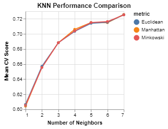

```python
import altair as alt

alt.Chart(results_KNN,
          title='KNN Performance Comparison'
         ).mark_line(point=True).encode(
    alt.X('n_neighbors', title='Number of Neighbors'),
    alt.Y('test_score', title='Mean CV Score', scale=alt.Scale(zero=False)),
    color='metric'
)
```

### Decision Tree (DT) Hyperparameter Tuning and Visualization

Moving on the second classifier is the Decision Tree, the same procedure was applied to obtain the optimal parameters.

The following was indentified to perform GridSearchCV:

- identify the Decision Tree Classifier as estimator
- a dictionary of Dt parameters: split `criterion` either gini or entropy, maximum depth `max_depth`, and minimum samples split `min_samples_split` parameters.
- include the abovementioned cross validation method `cv_method`
- a scoring metric of `roc_auc`
- last step is to fit a DT model using the training set

```python
from sklearn.tree import DecisionTreeClassifier
dt_classifier = DecisionTreeClassifier(random_state=999)

params_DT = {'criterion': ['gini', 'entropy'],
             'max_depth': [1, 2, 3, 4, 5, 6, 7, 8],
             'min_samples_split': [2, 3]}

gs_DT = GridSearchCV(estimator=dt_classifier,
                     param_grid=params_DT,
                     cv=cv_method,
                     verbose=1,
                     scoring='roc_auc')

gs_DT.fit(D_train, t_train);
```

```
Fitting 5 folds for each of 32 candidates, totalling 160 fits
```

```
[Parallel(n_jobs=1)]: Using backend SequentialBackend with 1 concurrent workers.
[Parallel(n_jobs=1)]: Done 160 out of 160 | elapsed:    2.3s finished
```

It is important to note the current parameters without Hyperparameter tuning to be able to compare it with the optimal parameters from GridSearch.

```python
from pprint import pprint
print('Parameters of Decision Tree without Hyperparameter Tuning:\n')
dt_clf_params = dt_classifier.get_params()
dt_clf_params
```

```
Parameters of Decision Tree without Hyperparameter Tuning:
```

```
{'class_weight': None,
 'criterion': 'gini',
 'max_depth': None,
 'max_features': None,
 'max_leaf_nodes': None,
 'min_impurity_decrease': 0.0,
 'min_impurity_split': None,
 'min_samples_leaf': 1,
 'min_samples_split': 2,
 'min_weight_fraction_leaf': 0.0,
 'presort': False,
 'random_state': 999,
 'splitter': 'best'}
```

The optimal parameters were identified as `criterion` = entropy, `max_depth` = 4, and `min_samples_split`= 2

```python
print('Parameters of Decision Tree with Hyperparameter GridSearch:\n')
dt_clf_bestparams = gs_DT.best_params_
dt_clf_bestparams
```

```
Parameters of Decision Tree with Hyperparameter GridSearch:
```

```
{'criterion': 'entropy', 'max_depth': 4, 'min_samples_split': 2}
```

It can be observed in the comparison summary below, is the change of DT parameters without hyperparameter tuning into its optimal parameters using Grid Search.

```python
#Summary of parameter comparison
comparison_params = pd.DataFrame(columns=['Decision Tree Parameters', 'Without Hyperparameter Tuning', 'With Hyperparameter Tuning - Grid Search'])
comparison_params.loc[len(comparison_params)] = ['criterion', dt_clf_params.get('criterion'), dt_clf_bestparams.get('criterion')]
comparison_params.loc[len(comparison_params)] = ['max_depth', dt_clf_params.get('max_depth'), dt_clf_bestparams.get('max_depth')]
comparison_params.loc[len(comparison_params)] = ['min_samples_split', dt_clf_params.get('min_samples_split'), dt_clf_bestparams.get('min_samples_split')]
comparison_params
```

|  | Decision Tree Parameters | Without Hyperparameter Tuning | With Hyperparameter Tuning - Grid Search |
| --- | --- | --- | --- |
| 0 | criterion | gini | entropy |
| 1 | max_depth | None | 4 |
| 2 | min_samples_split | 2 | 2 |

We can also observe that the optimal DT model has a mean AUC score of 0.76.

```python
print("Decision Tree AUC Score:",gs_DT.best_score_.round(3))
```

```
Decision Tree AUC Score: 0.76
```

To visualize the mean AUC score of the optimal DT model, the table and plot below shows that the gridsearch parameters of `criterion` = entropy, `max_depth` = 4, and `min_samples_split`= 2 outperforms the AUC score of other parameter combinations.

```python
results_DT = pd.DataFrame(gs_DT.cv_results_['params'])
results_DT['test_score'] = gs_DT.cv_results_['mean_test_score']
results_DT.head().round(3)
```

|  | criterion | max_depth | min_samples_split | test_score |
| --- | --- | --- | --- | --- |
| 0 | gini | 1 | 2 | 0.678 |
| 1 | gini | 1 | 3 | 0.678 |
| 2 | gini | 2 | 2 | 0.699 |
| 3 | gini | 2 | 3 | 0.699 |
| 4 | gini | 3 | 2 | 0.715 |

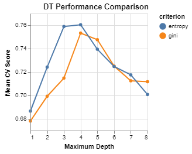

```python
alt.Chart(results_DT,
          title='DT Performance Comparison'
         ).mark_line(point=True).encode(
    alt.X('max_depth', title='Maximum Depth'),
    alt.Y('test_score', title='Mean CV Score', aggregate='average', scale=alt.Scale(zero=False)),
    color='criterion'
)
```

### Random Forest Hyperparameter Tuning and Visualization

the third classifier is the Random Forest, the same procedure was applied to obtain the optimal parameters.

```python
from sklearn.model_selection import GridSearchCV

# Create  model
rf_classifier = RandomForestClassifier(random_state=999)

# Create the parameter grid
param_RF = {
    'bootstrap': [True],
    'criterion' :['gini', 'entropy'],
    'max_depth': [1,2,3,4,5,6,7,8],
    'max_features': ['auto', 'sqrt', 'log2'],
    'min_samples_leaf': [1, 2,3,4,5],
    'min_samples_split': [2,3,4,5],
}
gs_RF = GridSearchCV(estimator = rf_classifier,
                     param_grid = param_RF,
                     cv = cv_method,
                     n_jobs = -1,
                     verbose = 1)

gs_RF.fit(D_train, t_train);
```

```
Fitting 5 folds for each of 960 candidates, totalling 4800 fits
```

```
[Parallel(n_jobs=-1)]: Using backend LokyBackend with 2 concurrent workers.
[Parallel(n_jobs=-1)]: Done 135 tasks      | elapsed:    8.5s
[Parallel(n_jobs=-1)]: Done 1035 tasks      | elapsed:   31.8s
[Parallel(n_jobs=-1)]: Done 2535 tasks      | elapsed:  1.3min
[Parallel(n_jobs=-1)]: Done 4635 tasks      | elapsed:  2.3min
[Parallel(n_jobs=-1)]: Done 4797 out of 4800 | elapsed:  2.4min remaining:    0.1s
[Parallel(n_jobs=-1)]: Done 4800 out of 4800 | elapsed:  2.4min finished
```

It is important to note the current parameters without Hyperparameter tuning to be able to compare it with the optimal parameters from GridSearch.

```python
from pprint import pprint
print('Parameters of Random Forest without Hyperparameter Tuning:\n')
rf_clf_params = rf_classifier.get_params()
rf_clf_params
```

```
Parameters of Random Forest without Hyperparameter Tuning:
```

```
{'bootstrap': True,
 'class_weight': None,
 'criterion': 'gini',
 'max_depth': None,
 'max_features': 'auto',
 'max_leaf_nodes': None,
 'min_impurity_decrease': 0.0,
 'min_impurity_split': None,
 'min_samples_leaf': 1,
 'min_samples_split': 2,
 'min_weight_fraction_leaf': 0.0,
 'n_estimators': 'warn',
 'n_jobs': None,
 'oob_score': False,
 'random_state': 999,
 'verbose': 0,
 'warm_start': False}
```

The optimal parameters were identified as `criterion` = entropy, `max_depth` = 7, `max_features` = auto, `min_samples_leaf` = 3, and `min_samples_split` = 2.

```python
print('Parameters of Random Forest with Hyperparameter GridSearch:\n')
rf_clf_bestparams = gs_RF.best_params_
rf_clf_bestparams
```

```
Parameters of Random Forest with Hyperparameter GridSearch:
```

```
{'bootstrap': True,
 'criterion': 'entropy',
 'max_depth': 7,
 'max_features': 'auto',
 'min_samples_leaf': 3,
 'min_samples_split': 2}
```

It can be observed in the comparison summary below, is the change of RF parameters without hyperparameter tuning into its optimal parameters using Grid Search.

```python
comparison_params = pd.DataFrame(columns=['Random Forest Parameters', 'Without Hyperparameter Tuning', 'With Hyperparameter Tuning - Grid Search'])
comparison_params.loc[len(comparison_params)] = ['criterion', rf_clf_params.get('criterion'), rf_clf_bestparams.get('criterion')]
comparison_params.loc[len(comparison_params)] = ['max_depth', rf_clf_params.get('max_depth'), rf_clf_bestparams.get('max_depth')]
comparison_params.loc[len(comparison_params)] = ['min_samples_leaf', rf_clf_params.get('min_samples_leaf'), rf_clf_bestparams.get('min_samples_leaf')]
comparison_params.loc[len(comparison_params)] = ['min_samples_split', rf_clf_params.get('min_samples_split'), rf_clf_bestparams.get('min_samples_split')]
comparison_params
```

|  | Random Forest Parameters | Without Hyperparameter Tuning | With Hyperparameter Tuning - Grid Search |
| --- | --- | --- | --- |
| 0 | criterion | gini | entropy |
| 1 | max_depth | None | 7 |
| 2 | min_samples_leaf | 1 | 3 |
| 3 | min_samples_split | 2 | 2 |

```python
print("Random Forest AUC Score:", gs_RF.best_score_.round(3))
```

```
Random Forest AUC Score: 0.892
```

```python
results_RF = pd.DataFrame(gs_RF.cv_results_['params'])
results_RF['test_score'] = gs_RF.cv_results_['mean_test_score']
results_RF.head().round(3)
```

|  | bootstrap | criterion | max_depth | max_features | min_samples_leaf | min_samples_split | test_score |
| --- | --- | --- | --- | --- | --- | --- | --- |
| 0 | True | gini | 1 | auto | 1 | 2 | 0.885 |
| 1 | True | gini | 1 | auto | 1 | 3 | 0.885 |
| 2 | True | gini | 1 | auto | 1 | 4 | 0.885 |
| 3 | True | gini | 1 | auto | 1 | 5 | 0.885 |
| 4 | True | gini | 1 | auto | 2 | 2 | 0.885 |

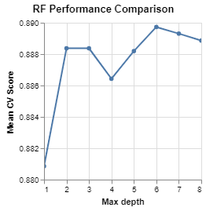

```python
alt.Chart(results_RF,
          title='RF Performance Comparison'
         ).mark_line(point=True).encode(
    alt.X('max_depth', title='Max depth'),
    alt.Y('test_score', title='Mean CV Score', aggregate='average', scale=alt.Scale(zero=False))
).interactive()
```

### Gaussian Naive Bayes Hyperparameter Tuning and Visualization

The fourth classifier is the Naive Bayes, the same procedure was applied to obtain the optimal parameters.

The following was indentified to perform GridSearchCV:

- identify the GaussianNB Classifier as estimator
- a dictionary of the only RF parameter: `var_smooting`
- include the abovementioned cross validation method `cv_method`
- a scoring metric of `roc_auc`
- a power transformation to transform the Gaussian distribution to a normal distribution
- last step is to fit a RF model using the training set

```python
from sklearn.naive_bayes import GaussianNB
from sklearn.preprocessing import PowerTransformer

np.random.seed(999)

nb_classifier = GaussianNB()

# Create the parameter grid
params_NB = {'var_smoothing': np.logspace(0,-9, num=100)}

gs_NB = GridSearchCV(estimator=nb_classifier,
                     param_grid=params_NB,
                     cv=cv_method,
                     verbose=1,
                     scoring='roc_auc')

Data_transformed = PowerTransformer().fit_transform(D_train)

gs_NB.fit(Data_transformed, t_train);
```

```
Fitting 5 folds for each of 100 candidates, totalling 500 fits
```

```
[Parallel(n_jobs=1)]: Using backend SequentialBackend with 1 concurrent workers.
[Parallel(n_jobs=1)]: Done 500 out of 500 | elapsed:    8.2s finished
```

It is important to note the current parameters without Hyperparameter tuning to be able to compare it with the optimal parameters from GridSearch.

```python
from pprint import pprint
print('Parameters of Naive Bayes without Hyperparameter Tuning:\n')
nb_clf_params = nb_classifier.get_params()
nb_clf_params
```

```
Parameters of Naive Bayes without Hyperparameter Tuning:
```

```
{'priors': None, 'var_smoothing': 1e-09}
```

```python
print('Parameters of Naive Bayes with Hyperparameter GridSearch:\n')
nb_clf_bestparams = gs_NB.best_params_
nb_clf_bestparams
```

```
Parameters of Naive Bayes with Hyperparameter GridSearch:
```

```
{'var_smoothing': 0.657933224657568}
```

It can be observed in the comparison summary below, is the change of NB parameters without hyperparameter tuning into its optimal parameters using Grid Search.

```python
comparison_params = pd.DataFrame(columns=['Naive Bayes Parameters', 'Without Hyperparameter Tuning', 'With Hyperparameter Tuning - Grid Search'])
comparison_params.loc[len(comparison_params)] = ['var_smoothing', nb_clf_params.get('var_smoothing'), nb_clf_bestparams.get('var_smoothing')]
comparison_params
```

|  | Naive Bayes Parameters | Without Hyperparameter Tuning | With Hyperparameter Tuning - Grid Search |
| --- | --- | --- | --- |
| 0 | var_smoothing | 1.000000e-09 | 0.657933 |

We can also observe that the optimal NB model has a mean AUC score of 0.755.

```python
print("Naive Bayes AUC Score:",gs_NB.best_score_.round(3))
```

```
Naive Bayes AUC Score: 0.755
```

```python
results_NB = pd.DataFrame(gs_NB.cv_results_['params'])
results_NB['test_score'] = gs_NB.cv_results_['mean_test_score']
results_NB.head().round(3)
```

|  | var_smoothing | test_score |
| --- | --- | --- |
| 0 | 1.000 | 0.755 |
| 1 | 0.811 | 0.755 |
| 2 | 0.658 | 0.755 |
| 3 | 0.534 | 0.755 |
| 4 | 0.433 | 0.755 |

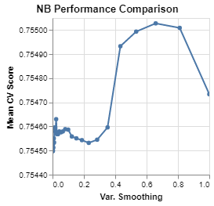

```python
alt.Chart(results_NB,
          title='NB Performance Comparison'
         ).mark_line(point=True).encode(
    alt.X('var_smoothing', title='Var. Smoothing'),
    alt.Y('test_score', title='Mean CV Score', aggregate='average',scale=alt.Scale(zero=False))
).interactive()
```

### SVM Hyperparameter Tuning and Visualization

The fifth and final classifier is the SVM, the same procedure was applied to obtain the optimal parameters.

The following was indentified to perform GridSearchCV:

- identify the SVM Classifier as estimator
- a dictionary of the only RF parameter: `C`, `gamma` and `kernel`
- include the abovementioned cross validation method `cv_method`
- a scoring metric of `roc_auc`
- last step is to fit a RF model using the training set

```python
from sklearn.svm import SVC
svm_classifier = SVC(random_state=999)

param_SVM = {'C': [0.1, 1, 10, 100, 1000],
              'gamma': [1, 0.1, 0.01, 0.001, 0.0001],
              'kernel': ['rbf', 'poly']}


gs_SVM = GridSearchCV(estimator = svm_classifier,
                      param_grid = param_SVM,
                      cv =cv_method,
                      refit = True,
                      verbose = 1,
                      n_jobs = -1,
                     scoring='roc_auc')

gs_SVM.fit(D_train, t_train);
```

```
Fitting 5 folds for each of 50 candidates, totalling 250 fits
```

```
[Parallel(n_jobs=-1)]: Using backend LokyBackend with 2 concurrent workers.
[Parallel(n_jobs=-1)]: Done  46 tasks      | elapsed:    9.7s
[Parallel(n_jobs=-1)]: Done 196 tasks      | elapsed:   46.2s
[Parallel(n_jobs=-1)]: Done 250 out of 250 | elapsed:  1.2min finished
```

It is important to note the current parameters without Hyperparameter tuning to be able to compare it with the optimal parameters from GridSearch.

```python
from pprint import pprint
print('Parameters of SVM without Hyperparameter Tuning:\n')
svm_clf_params = svm_classifier.get_params()
svm_clf_params
```

```
Parameters of SVM without Hyperparameter Tuning:
```

```
{'C': 1.0,
 'cache_size': 200,
 'class_weight': None,
 'coef0': 0.0,
 'decision_function_shape': 'ovr',
 'degree': 3,
 'gamma': 'auto_deprecated',
 'kernel': 'rbf',
 'max_iter': -1,
 'probability': False,
 'random_state': 999,
 'shrinking': True,
 'tol': 0.001,
 'verbose': False}
```

The optimal parameters were identified as `C` = 1000, `gamma` = 0.001, and `kernel` = rbf.

```python
print('Parameters of SVM with Hyperparameter GridSearch:\n')
svm_clf_bestparams = gs_SVM.best_params_
svm_clf_bestparams
```

```
Parameters of SVM with Hyperparameter GridSearch:
```

```
{'C': 1000, 'gamma': 0.001, 'kernel': 'rbf'}
```

It can be observed in the comparison summary below, is the change of SVM parameters without hyperparameter tuning into its optimal parameters using Grid Search.

```python
comparison_params = pd.DataFrame(columns=['SVM Parmeters', 'Without Hyperparameter Tuning', 'With Hyperparameter Tuning - Grid Search'])
comparison_params.loc[len(comparison_params)] = ['C', svm_clf_params.get('C'), svm_clf_bestparams.get('C')]
comparison_params.loc[len(comparison_params)] = ['gamma', svm_clf_params.get('gamma'), svm_clf_bestparams.get('gamma')]
comparison_params.loc[len(comparison_params)] = ['kernel', svm_clf_params.get('kernel'), svm_clf_bestparams.get('kernel')]
comparison_params
```

|  | SVM Parmeters | Without Hyperparameter Tuning | With Hyperparameter Tuning - Grid Search |
| --- | --- | --- | --- |
| 0 | C | 1 | 1000 |
| 1 | gamma | auto_deprecated | 0.001 |
| 2 | kernel | rbf | rbf |

We can also observe that the optimal SVM model has a mean AUC score of 0.76.

```python
print("SVM AUC Score:",gs_SVM.best_score_.round(3))
```

```
SVM AUC Score: 0.76
```

To visualize the mean AUC score of the optimal SVM model, the table and plot below shows that the gridsearch parameters of `C` = 1000, `gamma` = 0.001, and `kernel` = rbf outperforms the AUC score of other parameter combinations.

```python
results_SVM = pd.DataFrame(gs_SVM.cv_results_['params'])
results_SVM['test_score'] = gs_SVM.cv_results_['mean_test_score']
results_SVM.head()
```

|  | C | gamma | kernel | test_score |
| --- | --- | --- | --- | --- |
| 0 | 0.1 | 1.00 | rbf | 0.688054 |
| 1 | 0.1 | 1.00 | poly | 0.641644 |
| 2 | 0.1 | 0.10 | rbf | 0.703118 |
| 3 | 0.1 | 0.10 | poly | 0.684939 |
| 4 | 0.1 | 0.01 | rbf | 0.702234 |

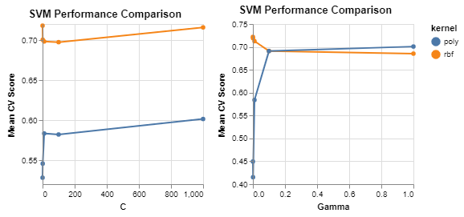

```python
C= alt.Chart(results_SVM,
          title='SVM Performance Comparison'
         ).mark_line(point=True).encode(
    alt.X('C', title='C'),
    alt.Y('test_score', title='Mean CV Score', aggregate='average', scale=alt.Scale(zero=False)),
    color='kernel')

gamma= alt.Chart(results_SVM,
          title='SVM Performance Comparison'
         ).mark_line(point=True).encode(
    alt.X('gamma', title='Gamma'),
    alt.Y('test_score', title='Mean CV Score', aggregate='average', scale=alt.Scale(zero=False)),
    color='kernel')

C | gamma
```

### Summary of AUC score of Train data with Hyperparameter Tuning stratified 5-fold cross-validation

```python
comparison_AUC = pd.DataFrame(columns = ['Classifier',  '5-fold CV AUC Score'])
comparison_AUC.loc[len(comparison_AUC)] = ['KNN', gs_KNN.best_score_]
comparison_AUC.loc[len(comparison_AUC)] = ['Decision Tree', gs_DT.best_score_]
comparison_AUC.loc[len(comparison_AUC)] = ['Random Forest', gs_RF.best_score_]
comparison_AUC.loc[len(comparison_AUC)] = ['Naive Bayes', gs_NB.best_score_]
comparison_AUC.loc[len(comparison_AUC)] = ['SVM', gs_SVM.best_score_]
comparison_AUC.round(3)
```

|  | Classifier | 5-fold CV AUC Score |
| --- | --- | --- |
| 0 | KNN | 0.726 |
| 1 | Decision Tree | 0.760 |
| 2 | Random Forest | 0.892 |
| 3 | Naive Bayes | 0.755 |
| 4 | SVM | 0.760 |

# Model Evaluation: Performance Comparison

Each of the classifiers will now be fitted on the 1500 rows of test data using a 10-fold stratified cross-validation without repetition with the same random state than with which each of the previous three cross-validation runs were applied. By fitting the classifiers in the test data, the performance of each will be measured.

Nonetheless, considering the randomness nature of cross valdation processes, a pairwise t-test will be conducted between the AUC score obtained between each of the tuned classifiers.

## Fit the classifiers with Stratified 10-fold Cross Validation

```python
from sklearn.model_selection import StratifiedKFold

cv_method_ttest = StratifiedKFold(n_splits=10, random_state=999)
```

```python
from sklearn.model_selection import cross_val_score

cv_results_KNN = cross_val_score(estimator=gs_KNN.best_estimator_,
                                 X=D_test,
                                 y=t_test,
                                 cv=cv_method_ttest,
                                 n_jobs=-2,
                                 scoring='roc_auc')
cv_results_KNN.mean().round(3)
```

```
0.699
```

```python
cv_results_DT = cross_val_score(estimator=gs_DT.best_estimator_,
                                X=D_test,
                                y=t_test,
                                cv=cv_method_ttest,
                                n_jobs=-2,
                                scoring='roc_auc')
cv_results_DT.mean().round(3)
```

```
0.7
```

```python
cv_results_RF = cross_val_score(estimator=gs_RF.best_estimator_,
                                X=D_test,
                                y=t_test,
                                cv=cv_method_ttest,
                                n_jobs=-2,
                                scoring='roc_auc')
cv_results_RF.mean().round(3)
```

```
0.732
```

```python
D_test_transformed = PowerTransformer().fit_transform(D_test)

cv_results_NB = cross_val_score(estimator=gs_NB.best_estimator_,
                                X=D_test_transformed,
                                y=t_test,
                                cv=cv_method_ttest,
                                n_jobs=-2,
                                scoring='roc_auc')
cv_results_NB.mean().round(3)
```

```
0.727
```

```python
cv_results_SVM = cross_val_score(estimator=gs_SVM.best_estimator_,
                                X=D_test,
                                y=t_test,
                                cv=cv_method_ttest,
                                n_jobs=-2,
                                scoring='roc_auc')
cv_results_SVM.mean().round(3)
```

```
0.688
```

## Summary of AUC score on Test data

```python
comparison_CV_AUC = pd.DataFrame(columns = ['Classifier',  '10-fold CV AUC Score'])
comparison_CV_AUC.loc[len(comparison_CV_AUC)] = ['KNN', cv_results_KNN.mean()]
comparison_CV_AUC.loc[len(comparison_CV_AUC)] = ['Decision Tree', cv_results_DT.mean()]
comparison_CV_AUC.loc[len(comparison_CV_AUC)] = ['Random Forest', cv_results_RF.mean()]
comparison_CV_AUC.loc[len(comparison_CV_AUC)] = ['Naive Bayes', cv_results_NB.mean()]
comparison_CV_AUC.loc[len(comparison_CV_AUC)] = ['SVM', cv_results_SVM.mean()]
comparison_CV_AUC.round(3)
```

|  | Classifier | 10-fold CV AUC Score |
| --- | --- | --- |
| 0 | KNN | 0.699 |
| 1 | Decision Tree | 0.700 |
| 2 | Random Forest | 0.732 |
| 3 | Naive Bayes | 0.727 |
| 4 | SVM | 0.688 |

## Paired t-test comparison of AUC Scores of Tuned Classifiers

Given that the classifiers' fittings on train and test sets were peformed under the same ("paired") conditions, it would be possible to run a pairwise t-test to evaluate the fits from as statistical approach.

```python
from scipy import stats

print("KNN vs. DT", stats.ttest_rel(cv_results_KNN, cv_results_DT))
print("KNN vs. RF",stats.ttest_rel(cv_results_KNN, cv_results_RF))
print("KNN vs. NB",stats.ttest_rel(cv_results_KNN, cv_results_NB))
print("KNN vs. SVM",stats.ttest_rel(cv_results_KNN, cv_results_SVM))
print("DT vs. RF",stats.ttest_rel(cv_results_DT, cv_results_RF))
print("DT vs. NB",stats.ttest_rel(cv_results_DT, cv_results_NB))
print("DT vs. SVM",stats.ttest_rel(cv_results_DT, cv_results_SVM))
print("RF vs. NB",stats.ttest_rel(cv_results_RF, cv_results_NB))
print("RF vs. SVM",stats.ttest_rel(cv_results_RF, cv_results_SVM))
print("NB vs. SVM",stats.ttest_rel(cv_results_NB, cv_results_SVM))
```

```
KNN vs. DT Ttest_relResult(statistic=-0.0601293932177203, pvalue=0.953366614249245)
KNN vs. RF Ttest_relResult(statistic=-2.0817611938407334, pvalue=0.06707341638921227)
KNN vs. NB Ttest_relResult(statistic=-1.582683631125113, pvalue=0.14795311820479634)
KNN vs. SVM Ttest_relResult(statistic=0.4231587886596241, pvalue=0.6821115193054403)
DT vs. RF Ttest_relResult(statistic=-1.9125070986765191, pvalue=0.0881073307201336)
DT vs. NB Ttest_relResult(statistic=-1.9507324689480956, pvalue=0.08286917646698755)
DT vs. SVM Ttest_relResult(statistic=0.6179288445081274, pvalue=0.551935814173531)
RF vs. NB Ttest_relResult(statistic=0.45862889695645315, pvalue=0.6573747266951764)
RF vs. SVM Ttest_relResult(statistic=1.8971174209002195, pvalue=0.09030329386242554)
NB vs. SVM Ttest_relResult(statistic=2.544878701398941, pvalue=0.031457963035236604)
```

## Classification Report

A Classififcation Report for each classifier will be generated to consider evaluate the models by metrics such as accuracy, precision, recall, F1 Score and confusion matrix. According to the results, all of the classifiers presented a high and equal F1 Score of 94, which accounts for the armonic average of precision and recall of the models. Decision Tree and Random Forest presented the highest TPR (recall) values, so that among the other classifiers, these are the best models to predict a true positive value outcome for the target feature.

```python
t_pred_KNN = gs_KNN.best_estimator_.predict(D_test)
t_pred_DT = gs_DT.best_estimator_.predict(D_test)
t_pred_RF = gs_RF.best_estimator_.predict(D_test)
t_pred_NB = gs_NB.best_estimator_.predict(D_test_transformed)
t_pred_SVM = gs_SVM.best_estimator_.predict(D_test)
```

```python
from sklearn import metrics
print("\nClassification report for K-Nearest Neighbor")
print(metrics.classification_report(t_test, t_pred_KNN))
print("\nClassification report for Decision Tree")
print(metrics.classification_report(t_test, t_pred_DT))
print("\nClassification report for Random Forest")
print(metrics.classification_report(t_test, t_pred_RF))
print("\nClassification report for Naive Bayes")
print(metrics.classification_report(t_test, t_pred_NB))
print("\nClassification report for SVM")
print(metrics.classification_report(t_test, t_pred_SVM))
```

```
Classification report for K-Nearest Neighbor
              precision    recall  f1-score   support

           0       0.91      0.98      0.94      1327
           1       0.59      0.27      0.37       173

   micro avg       0.89      0.89      0.89      1500
   macro avg       0.75      0.62      0.66      1500
weighted avg       0.87      0.89      0.88      1500


Classification report for Decision Tree
              precision    recall  f1-score   support

           0       0.91      0.97      0.94      1327
           1       0.56      0.28      0.38       173

   micro avg       0.89      0.89      0.89      1500
   macro avg       0.74      0.63      0.66      1500
weighted avg       0.87      0.89      0.88      1500


Classification report for Random Forest
              precision    recall  f1-score   support

           0       0.91      0.97      0.94      1327
           1       0.58      0.28      0.38       173

   micro avg       0.89      0.89      0.89      1500
   macro avg       0.75      0.63      0.66      1500
weighted avg       0.87      0.89      0.88      1500


Classification report for Naive Bayes
              precision    recall  f1-score   support

           0       0.91      0.97      0.94      1327
           1       0.49      0.24      0.32       173

   micro avg       0.88      0.88      0.88      1500
   macro avg       0.70      0.60      0.63      1500
weighted avg       0.86      0.88      0.87      1500


Classification report for SVM
              precision    recall  f1-score   support

           0       0.90      0.98      0.94      1327
           1       0.57      0.21      0.31       173

   micro avg       0.89      0.89      0.89      1500
   macro avg       0.74      0.59      0.62      1500
weighted avg       0.87      0.89      0.87      1500
```

## Confusion Matrix

The confusion matrices for each of the classifiers are given below. Based on these, Decision Tree and Random Forest have the highest TPR (recall) scores among the rest of the classifiers.

```python
from sklearn import metrics
print("\nConfusion matrix for K-Nearest Neighbor")
print(metrics.confusion_matrix(t_test, t_pred_KNN))
print("\nConfusion matrix for Decision Tree")
print(metrics.confusion_matrix(t_test, t_pred_DT))
print("\nConfusion matrix for Random Forest")
print(metrics.confusion_matrix(t_test, t_pred_RF))
print("\nConfusion matrix for Naive Bayes")
print(metrics.confusion_matrix(t_test, t_pred_NB))
print("\nConfusion matrix for SVM")
print(metrics.confusion_matrix(t_test, t_pred_SVM))
```

```
Confusion matrix for K-Nearest Neighbor
[[1295   32]
 [ 126   47]]

Confusion matrix for Decision Tree
[[1289   38]
 [ 124   49]]

Confusion matrix for Random Forest
[[1292   35]
 [ 125   48]]

Confusion matrix for Naive Bayes
[[1284   43]
 [ 132   41]]

Confusion matrix for SVM
[[1300   27]
 [ 137   36]]
```

# Limitations

There are definitely limitations to the modelling strategy that was done above.

The first one is that we can't interpret the reason behind the result from the machine learning system as we focus more on the performance of the prediction. In the future, we could explore further for feature selection as well as the hyperparameter tuning.

The second one is using power transformation only on the training data when hyperparameter tuning was performed on Naive Bayes classifier and ignoring the rest of the dummy data. That might cause the classifier to perform poorly when egvaltuated on test set. A possible solution is to build Naive Bayes on both the numerical and descriptive feature separately. As for the final prediction, it can be computed by multiplying the prediction from each model.

The third limitation is that we did not work with the full dataset in terms of observations. Only 5000 observations were taken to do training and testing. 5000 observations out of 41188 observations is merely slightly over 10% of the original dataset, which more or less will definitely affect the result. Without the limitation of the run time, we could try to use all of the observations for training and testing.

# Summary and Conclusions

Summary and Conclusions In this report, the goal was to predict whether the client will subscribe to a term deposit. We started with data preprocessing to clean the data. Data exploration was then done with visualizations to understand the data better.

Feature selection was performed next and 10 number of features were selected. In feature selection, we went through the filter methods and found that using just 10 features most of the time gives a better performance compared to using full set of features. In feature selection, F-Score feature selection method gives the best performance compared to the rest of the method and full set of features.

Using the 10 best features, the report proceed to hyperparameter tuning. The objective of doing hyperparameter tuning is to get the most optimal parameter in different classifiers. The classifiers that we used for comparison are K-Nearest Neighbor, Decision Tree, Random Forest, Naive Bayes and SVM.

After hyperparameter tuning, the report proceed on to model evaluation. In this part, we did performance comparison by fitting the test set on the classifiers and compared the average result. At this point we found that Random Forest gave the best performance according to the 10-fold AUC score. In classification report, we chose to use recall / TPR to detect whether the client will subscribe to a term deposit. In this case, Random Forest classifier together with Decision Tree classifier gives the best recall score for client who subscribed to term deposit. The confusion matrix results show the details of the prediction and are in line with the classification report as Decision Tree classifier has the highest True Positive followed by Random Forest classifier.

# References

- [Moro et al., 2014] S. Moro, P. Cortez and P. Rita. A Data-Driven Approach to Predict the Success of Bank Telemarketing. Decision Support Systems, Elsevier, 62:22-31, June 2014
- Bank Marketing Data Set. UCI Machine Learning Repository. Dataset obtained on 17 May 2020, from https://archive.ics.uci.edu/ml/datasets/Bank+Marketing
- Machine Learning Tutorials. Obtained from https://www.featureranking.com/tutorials/machine-learning-tutorials/
- OECD. (2020) Consumer Confidence Index (CCI). Organisation for Economic Co-operation and Develpoment. Obtained from https://data.oecd.org/leadind/consumer-confidence-index-cci.htm
- Feature Selection Using Random Forest. The Wisdom of Crowds. 15 December 2018, from https://towardsdatascience.com/feature-selection-using-random-forest-26d7b747597f